# IODS course project

Kukka-Maaria Polso

# Introduction to Open Data Science - Course Project

# About the project

*Write a short description about the course and add a link to your GitHub repository here. This is an R Markdown (.Rmd) file so you should use R Markdown syntax.*

```r
# This is a so-called "R chunk" where you can write R code.

date()
```

```
## [1] "Sun Dec 12 01:00:52 2021"
```

The text continues here.

I’m excited to see how longitudinal data is analysed using R and try that for myself. The course will probably require loads of work but that’s the only way these things can be learned. I got an email about the course and someone recommended it on a previous course, Data Visualization with R.

[Here](https://github.com/kukkispolso/IODS-project)’s a link to my GitHub repository.

# Week 2: Regression and model validation

*Describe the work you have done this week and summarize your learning.*

- Describe your work and results clearly.
- Assume the reader has an introductory course level understanding of writing and reading R code as well as statistical methods.
- Assume the reader has no previous knowledge of your data or the more advanced methods you are using.

```r
date()
```

```
## [1] "Sun Dec 12 01:00:52 2021"
```

**Exercise 1**  
This is the dataset that will be used for week 2 exercises. Data were collected with a questionnaire during a university course. Seven variables are included in the dataset. Variables for attitude towards statistics (attitude), deep learning (deep), strategic learning (stra), and surface learning (surf) were computed from several items. Students have also reported their gender and age. Additionally, a measure of course achievement (exam points) is included. Of the 183 students who responded to the questionnaire, those with zero points from the exam (n = 17) were excluded from this dataset, leaving 166 students in the dataset.

```r
students2014 <- read.csv("data/learning2014.csv")
str(students2014)
```

```
## 'data.frame':    166 obs. of  7 variables:
##  $ gender  : chr  "F" "M" "F" "M" ...
##  $ age     : int  53 55 49 53 49 38 50 37 37 42 ...
##  $ attitude: int  37 31 25 35 37 38 35 29 38 21 ...
##  $ deep    : num  3.58 2.92 3.5 3.5 3.67 ...
##  $ stra    : num  3.38 2.75 3.62 3.12 3.62 ...
##  $ surf    : num  2.58 3.17 2.25 2.25 2.83 ...
##  $ points  : int  25 12 24 10 22 21 21 31 24 26 ...
```

```r
dim(students2014)
```

```
## [1] 166   7
```

**Exercise 2**  
Here’s a graphical overview of the data, namely, scatter plots that show the relationships between the six non-discrete variables in the dataset. Colors represent males and females.

As can be seen in the summary of the gender variable, there are almost twice as many females than males in the dataset. The minimum and maximum values along with the means and medians of all the other variables are shown in the summaries as well.

Based on the plots and the summaries, it seems that most of the students have been in their 20s at the time of the course and that there seems to be a gap in the distribution of exam points somewhere around 15 points. There seems to be a positive relationship between attitude (towards statistics) and exam points.

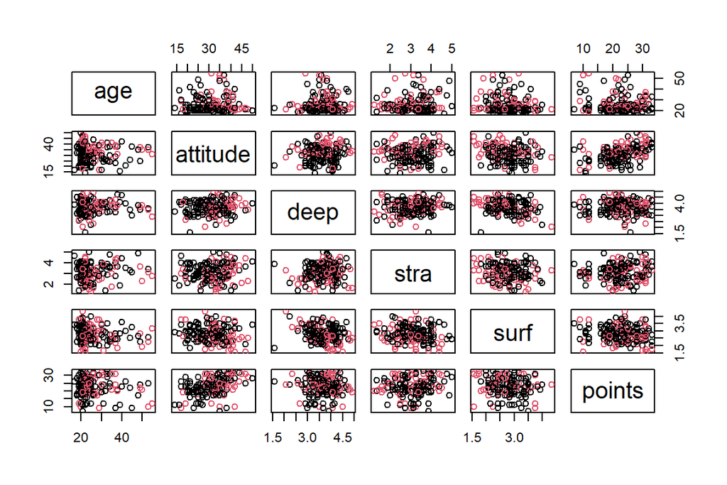

```r
students2014$gender <- as.factor(students2014$gender) #changing variable type from character to factor so that it can be used in the visualization

pairs(students2014[-1], col = students2014$gender)
```

```r
summary(students2014)
```

```
##  gender       age           attitude          deep            stra
##  F:110   Min.   :17.00   Min.   :14.00   Min.   :1.583   Min.   :1.250
##  M: 56   1st Qu.:21.00   1st Qu.:26.00   1st Qu.:3.333   1st Qu.:2.625
##          Median :22.00   Median :32.00   Median :3.667   Median :3.188
##          Mean   :25.51   Mean   :31.43   Mean   :3.680   Mean   :3.121
##          3rd Qu.:27.00   3rd Qu.:37.00   3rd Qu.:4.083   3rd Qu.:3.625
##          Max.   :55.00   Max.   :50.00   Max.   :4.917   Max.   :5.000
##       surf           points
##  Min.   :1.583   Min.   : 7.00
##  1st Qu.:2.417   1st Qu.:19.00
##  Median :2.833   Median :23.00
##  Mean   :2.787   Mean   :22.72
##  3rd Qu.:3.167   3rd Qu.:27.75
##  Max.   :4.333   Max.   :33.00
```

**Exercise 3**  
Here’s a regression model with exam points as the target variable and gender, age, and attitude as the explanatory variables. According to the summary of the fitted model, attitude is a statistically significant predictor of exam points: the better attitude, the more points in the exam.

The summary also reveals that gender and age do not have a significant relationship with exam points. These variables are removed in the second model. I also tried fitting models with one of these two as a second explanatory variable alongside attitude, but the results remained the same.

```r
points_model <- lm(points ~ gender + age + attitude, data = students2014) #gender, age, and attitude as explanatory variables
summary(points_model)
```

```
##
## Call:
## lm(formula = points ~ gender + age + attitude, data = students2014)
##
## Residuals:
##      Min       1Q   Median       3Q      Max
## -17.4590  -3.3221   0.2186   4.0247  10.4632
##
## Coefficients:
##             Estimate Std. Error t value Pr(>|t|)
## (Intercept) 13.42910    2.29043   5.863 2.48e-08 ***
## genderM     -0.33054    0.91934  -0.360    0.720
## age         -0.07586    0.05367  -1.414    0.159
## attitude     0.36066    0.05932   6.080 8.34e-09 ***
## ---
## Signif. codes:  0 '***' 0.001 '**' 0.01 '*' 0.05 '.' 0.1 ' ' 1
##
## Residual standard error: 5.315 on 162 degrees of freedom
## Multiple R-squared:  0.2018, Adjusted R-squared:  0.187
## F-statistic: 13.65 on 3 and 162 DF,  p-value: 5.536e-08
```

```r
points_model2 <- lm(points ~ attitude, data = students2014) #only attitude as an explanatory variable
summary(points_model2)
```

```
##
## Call:
## lm(formula = points ~ attitude, data = students2014)
##
## Residuals:
##      Min       1Q   Median       3Q      Max
## -16.9763  -3.2119   0.4339   4.1534  10.6645
##
## Coefficients:
##             Estimate Std. Error t value Pr(>|t|)
## (Intercept) 11.63715    1.83035   6.358 1.95e-09 ***
## attitude     0.35255    0.05674   6.214 4.12e-09 ***
## ---
## Signif. codes:  0 '***' 0.001 '**' 0.01 '*' 0.05 '.' 0.1 ' ' 1
##
## Residual standard error: 5.32 on 164 degrees of freedom
## Multiple R-squared:  0.1906, Adjusted R-squared:  0.1856
## F-statistic: 38.61 on 1 and 164 DF,  p-value: 4.119e-09
```

**Exercise 4**  
In the second model, exam points are explained by attitude towards statistics. The relationship is statistically significant and positive. The estimate can be interpreted as follows: if attitude increases by one unit, exam points increase by ~0.4 with a standard error of 0.06. With a minimum value of the explanatory variable (i.e., very poor attitude), a student would gain 11.6 points on average (with a std. error of 1.8).

However, the multiple R-squared statistic informs us that only 19% of the variation in exam points can be explained by attitude.

**Exercise 5**  
These figures represent diagnostics of the model residuals. There are four assumptions concerning the residuals of a regression model (the related diagnostic in parentheses):  
1. The errors are normally distributed (Q-Q-plot)  
2. The errors are not correlated #what’s the test for this assumption?  
3. The errors have a constant variance (Residuals vs Fitted)  
4. The size of a given error does not depend on the explanatory variables (Residuals vs Leverage)  
(source: DataCamp video ‘Model validation’, related diagnostics added by me)

As can be seen in the Q-Q-plot, points in the middle fit the line nicely but those in both ends slightly deviate from it. The deviations do not seem radical, suggesting a sufficient normality of the error distribution. However, since I’m not an experienced interpreted of Q-Q-plots, these interpretations should be taken with caution.

The relationship between residuals and model predictions is depicted in the Residuals vs Fitted scatter plot. Any kind of pattern would imply that there is a dependence between size of the errors and the explanatory variable(s). In this case, there seems to be no pattern in the plot, suggesting a constant variance of the errors.

Finally, the Residuals vs Leverage plot shows leverage points in the data. The plot helps to identify points with an unusually high impact on the model. The present model seems not to have points with extremely high leverage, suggesting that the errors are not dependent on the explanatory variables.

All in all, as far as I can tell, the assumptions seem to be met rather well here.

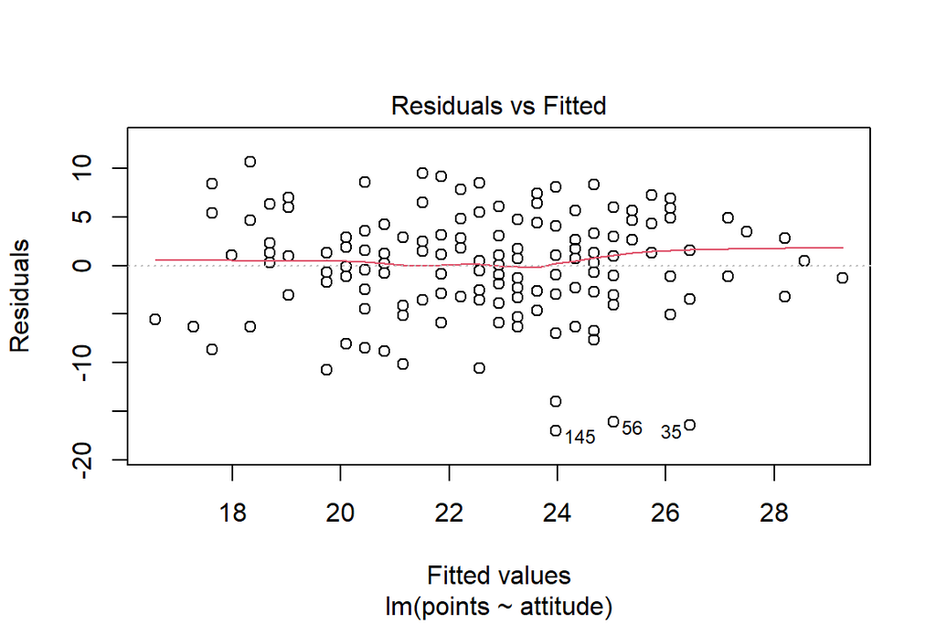

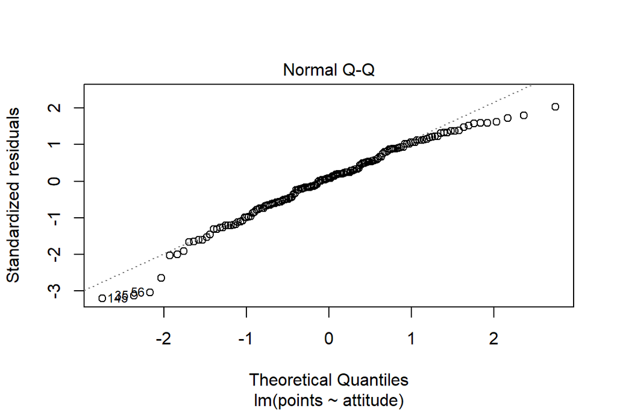

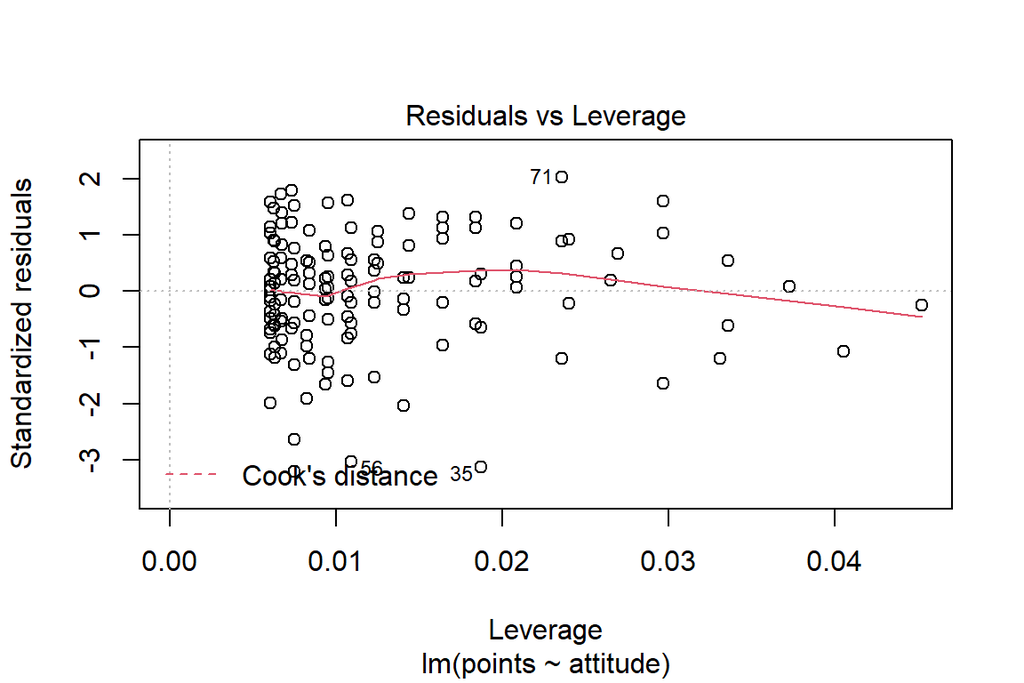

```r
plot(points_model2, which = c(1, 2, 5))
```

# Week 3: Logistic regression

**Exercise 2**  
First, I read the data from my local folder.

```r
getwd()
```

```
## [1] "C:/LocalData/xpoxpox/IODS-project"
```

```r
pormat <- read.csv("data/pormat.csv", sep = ",", header = T)
library(tidyr); library(dplyr); library(ggplot2)
```

The dataset at hand consists of Portuguese secondary school students’ (N = 370) background variables and achievement collected from school reports and by self-report questionnaires.

```r
colnames(pormat)
```

```
##  [1] "school"       "sex"          "age"          "address"      "famsize"
##  [6] "Pstatus"      "Medu"         "Fedu"         "Mjob"         "Fjob"
## [11] "reason"       "guardian"     "traveltime"   "studytime"    "failures.por"
## [16] "schoolsup"    "famsup"       "paid.por"     "activities"   "nursery"
## [21] "higher"       "internet"     "romantic"     "famrel"       "freetime"
## [26] "goout"        "Dalc"         "Walc"         "health"       "absences.por"
## [31] "G1.por"       "G2.por"       "G3.por"       "id.por"       "failures.mat"
## [36] "paid.mat"     "absences.mat" "G1.mat"       "G2.mat"       "G3.mat"
## [41] "id.mat"       "id"           "failures"     "paid"         "absences"
## [46] "G1"           "G2"           "G3"           "alc_use"      "high_use"
```

**Exercise 3**  
The purpose of your analysis is to study the relationships between high/low alcohol consumption and some of the other variables in the data. To do this, choose 4 interesting variables in the data and for each of them, present your personal hypothesis about their relationships with alcohol consumption.

There are many interesting variables in the data. I chose the following to further explore their relationships with alcohol consumption:

schoolsup - extra educational support (binary: yes or no) Medu - mother’s education (numeric: 0 - none, 1 - primary education (4th grade), 2 – 5th to 9th grade, 3 – secondary education or 4 – higher education) health - current health status (numeric: from 1 - very bad to 5 - very good) G3 - final grade (numeric: from 0 to 20, output target)

I think educational support may be positively related to higher consumption. There could be variables that explain both the need for support and alcohol consumption, such as socio-economic status or current health. That’s why I have mother’s education and health status there, too. I believe these variables are positively related to higher alcohol consumption. Finally, I assume that final grade and high alcohol consumption have a negative relationship.

**Exercise 4**  
Let’s begin by taking a look at my four chosen explanatory variables. Most students seem to come from quite educated families and consider themselves as healthy. The vast majority does not receive extra educational support. Students’ grades, although in peculiar order, seem to distribute quite normally.

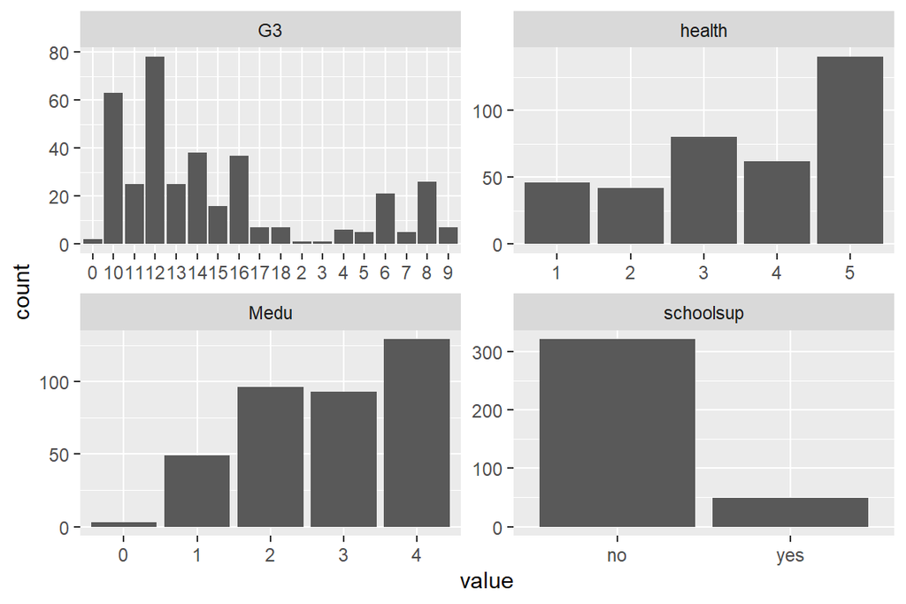

```r
pormat %>%
  select(schoolsup, Medu, health, G3) %>%
  gather() %>%
  ggplot(aes(value)) + facet_wrap("key", scales = "free") + geom_bar()
```

Next, I grouped the data by high use and summarised the distribution of students according to their consumption status and the chosen variables. The non-high users without special support seem to achieve the highest grades, but this might be due to the support status rather that the alcohol consumption status. High-consuming students with extra school support report highest health statuses, wchich is slightly surprising to me. However, there weren’t many of these students (n = 12). Mother’s education seems unrelated to alcohol consumption but somewhat related to support needs. Overall, my hypotheses weren’t that accurate…

```r
pormat %>%
  group_by(high_use, schoolsup) %>%
  summarise(count = n(), medu = mean(Medu), health = mean(health), grade = mean(G3))
```

```
## # A tibble: 4 x 6
## # Groups:   high_use [2]
##   high_use schoolsup count  medu health grade
##   <lgl>    <chr>     <int> <dbl>  <dbl> <dbl>
## 1 FALSE    no          222  2.82   3.53  12.0
## 2 FALSE    yes          37  2.68   3.27  10.5
## 3 TRUE     no           99  2.81   3.70  10.9
## 4 TRUE     yes          12  2.67   4     10.4
```

**Exercise 5**  
Now I will fit the logistic regression model. This is done to test my hypothesis that extra educational support, mother’s education, health status and final grade might be associated with alcohol consumption. As can be seen in the model summary, *only* grade is a statistically significant predictor of elevated alcohol consumption: students with higher grades are less likely to be high consumers. The effect is not large.

```r
model1 <- glm(high_use ~ schoolsup + Medu + health + G3, data = pormat, family = "binomial")

summary(model1)
```

```
##
## Call:
## glm(formula = high_use ~ schoolsup + Medu + health + G3, family = "binomial",
##     data = pormat)
##
## Deviance Residuals:
##     Min       1Q   Median       3Q      Max
## -1.2942  -0.8514  -0.7541   1.3795   1.8339
##
## Coefficients:
##              Estimate Std. Error z value Pr(>|z|)
## (Intercept)  -0.29578    0.57970  -0.510   0.6099
## schoolsupyes -0.39325    0.35746  -1.100   0.2713
## Medu          0.05931    0.10996   0.539   0.5896
## health        0.10140    0.08417   1.205   0.2283
## G3           -0.09120    0.03606  -2.529   0.0114 *
## ---
## Signif. codes:  0 '***' 0.001 '**' 0.01 '*' 0.05 '.' 0.1 ' ' 1
##
## (Dispersion parameter for binomial family taken to be 1)
##
##     Null deviance: 452.04  on 369  degrees of freedom
## Residual deviance: 442.52  on 365  degrees of freedom
## AIC: 452.52
##
## Number of Fisher Scoring iterations: 4
```

Similarly, while the following table shows that the other variables have 1 in their confidence intervals of the odds ratios, implying a non-signigicant relationship, it is clear that only grade is a statistically significant predictor of high alcohol consumption. The odds ratio of 0.91 suggests that if grade increases by 1, it is 0.91 times as likely to be a high consumer according to the model (that is, there is a ~9% decrease in the likelihood). [I’m NOT at all sure if my interpretation was correct, so if it sounds *odd*, please don’t get confused!]

```r
# compute odds ratios (OR)
OR <- coef(model1) %>% exp

# compute confidence intervals (CI)
CI <- confint(model1) %>% exp
# print out the odds ratios with their confidence intervals
cbind(OR, CI)
```

```
##                     OR     2.5 %   97.5 %
## (Intercept)  0.7439513 0.2365768 2.311188
## schoolsupyes 0.6748594 0.3227619 1.325167
## Medu         1.0611035 0.8566359 1.319540
## health       1.1067187 0.9400092 1.308456
## G3           0.9128369 0.8498542 0.979314
```

**Exercise 6**  
For the last exercise, I will fit a model with only grade as an explanatory variable.

```r
model2 <- glm(high_use ~ G3, data = pormat, family = "binomial")

summary(model2)
```

```
##
## Call:
## glm(formula = high_use ~ G3, family = "binomial", data = pormat)
##
## Deviance Residuals:
##     Min       1Q   Median       3Q      Max
## -1.2365  -0.8551  -0.7651   1.4213   1.7731
##
## Coefficients:
##             Estimate Std. Error z value Pr(>|z|)
## (Intercept)  0.13783    0.40374   0.341   0.7328
## G3          -0.08689    0.03466  -2.507   0.0122 *
## ---
## Signif. codes:  0 '***' 0.001 '**' 0.01 '*' 0.05 '.' 0.1 ' ' 1
##
## (Dispersion parameter for binomial family taken to be 1)
##
##     Null deviance: 452.04  on 369  degrees of freedom
## Residual deviance: 445.68  on 368  degrees of freedom
## AIC: 449.68
##
## Number of Fisher Scoring iterations: 4
```

Next, I try to provide a cross tabulation of predictions versus the actual values and display a graphic visualizing both the actual values and the predictions. I have no idea what I just did. The model doesn’t make sense to me! It seems like the model is highly inaccurate, doesn’t it? Unfortunately, I can’t afford more time for learning to interpret this kind of models at this point.

```r
probabilities <- predict(model2, type = "response")

# add the predicted probabilities to 'pormat'
pormat <- mutate(pormat, probability = probabilities)

# use the probabilities to make a prediction of high_use
pormat <- mutate(pormat, prediction = probabilities > 0.5)

# see the last ten original classes, predicted probabilities, and class predictions
select(pormat, G3, high_use, probability, prediction) %>% tail(10)
```

```
##     G3 high_use probability prediction
## 361 13    FALSE   0.2705712      FALSE
## 362  0    FALSE   0.5344029       TRUE
## 363  2     TRUE   0.4910139      FALSE
## 364 12    FALSE   0.2880574      FALSE
## 365  8    FALSE   0.3641766      FALSE
## 366  5    FALSE   0.4263851      FALSE
## 367 12    FALSE   0.2880574      FALSE
## 368  4    FALSE   0.4477598      FALSE
## 369 13     TRUE   0.2705712      FALSE
## 370 10     TRUE   0.3249622      FALSE
```

```r
# tabulate the target variable versus the predictions
table(high_use = pormat$high_use, prediction = pormat$prediction)
```

```
##         prediction
## high_use FALSE TRUE
##    FALSE   258    1
##    TRUE    110    1
```

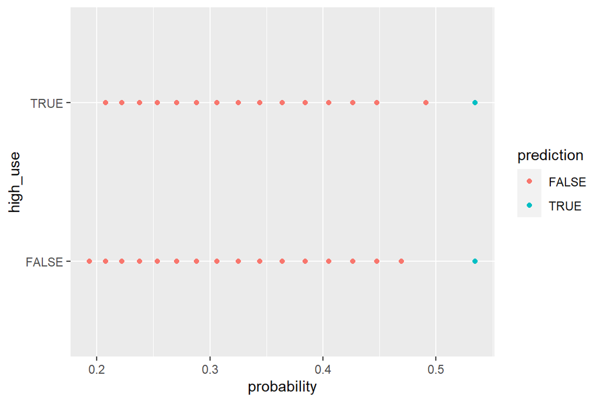

```r
g <- ggplot(pormat, aes(x = probability, y = high_use, col = prediction))

# define the geom as points and draw the plot
g + geom_point()
```

```r
# tabulate the target variable versus the predictions
table(high_use = pormat$high_use, prediction = pormat$prediction) %>% prop.table() %>% addmargins()
```

```
##         prediction
## high_use       FALSE        TRUE         Sum
##    FALSE 0.697297297 0.002702703 0.700000000
##    TRUE  0.297297297 0.002702703 0.300000000
##    Sum   0.994594595 0.005405405 1.000000000
```

Last, I will compute the total proportion of inaccurately classified individuals (= the training error) by defining a loss function and computing the average number of wrong predictions. In the DataCamp exercises, a similar function resulted in a penalty of 0.26. At least compared to that, the penalty of 0.3 doesn’t seem fatal.

```r
loss_func <- function(class, prob) {
  n_wrong <- abs(class - prob) > 0.5
  mean(n_wrong)
}

# call loss_func to compute the average number of wrong predictions in the (training) data
loss_func(class = pormat$high_use, prob = pormat$probability)
```

```
## [1] 0.3
```

```r
library(boot)
cv <- cv.glm(data = pormat, cost = loss_func, glmfit = model2, K = 10)

cv$delta[1]
```

```
## [1] 0.3
```

```r
library(boot)
cv <- cv.glm(data = pormat, cost = loss_func, glmfit = model2, K = 2)

cv$delta[1]
```

```
## [1] 0.3
```

# Week 4: Clustering and classification

**Exercise 2**  
Here’s the Boston dataset, which contains data of 506 Boston suburbs. There are 14 variables describing housing values, i.e. some socio-economical and geographical features of the Bostonian suburbs. Declaration of all 14 variables can be found [here](https://stat.ethz.ch/R-manual/R-devel/library/MASS/html/Boston.html).

```r
library(MASS)
library(dplyr)
data("Boston")
glimpse(Boston)
```

```
## Rows: 506
## Columns: 14
## $ crim    <dbl> 0.00632, 0.02731, 0.02729, 0.03237, 0.06905, 0.02985, 0.08829,~
## $ zn      <dbl> 18.0, 0.0, 0.0, 0.0, 0.0, 0.0, 12.5, 12.5, 12.5, 12.5, 12.5, 1~
## $ indus   <dbl> 2.31, 7.07, 7.07, 2.18, 2.18, 2.18, 7.87, 7.87, 7.87, 7.87, 7.~
## $ chas    <int> 0, 0, 0, 0, 0, 0, 0, 0, 0, 0, 0, 0, 0, 0, 0, 0, 0, 0, 0, 0, 0,~
## $ nox     <dbl> 0.538, 0.469, 0.469, 0.458, 0.458, 0.458, 0.524, 0.524, 0.524,~
## $ rm      <dbl> 6.575, 6.421, 7.185, 6.998, 7.147, 6.430, 6.012, 6.172, 5.631,~
## $ age     <dbl> 65.2, 78.9, 61.1, 45.8, 54.2, 58.7, 66.6, 96.1, 100.0, 85.9, 9~
## $ dis     <dbl> 4.0900, 4.9671, 4.9671, 6.0622, 6.0622, 6.0622, 5.5605, 5.9505~
## $ rad     <int> 1, 2, 2, 3, 3, 3, 5, 5, 5, 5, 5, 5, 5, 4, 4, 4, 4, 4, 4, 4, 4,~
## $ tax     <dbl> 296, 242, 242, 222, 222, 222, 311, 311, 311, 311, 311, 311, 31~
## $ ptratio <dbl> 15.3, 17.8, 17.8, 18.7, 18.7, 18.7, 15.2, 15.2, 15.2, 15.2, 15~
## $ black   <dbl> 396.90, 396.90, 392.83, 394.63, 396.90, 394.12, 395.60, 396.90~
## $ lstat   <dbl> 4.98, 9.14, 4.03, 2.94, 5.33, 5.21, 12.43, 19.15, 29.93, 17.10~
## $ medv    <dbl> 24.0, 21.6, 34.7, 33.4, 36.2, 28.7, 22.9, 27.1, 16.5, 18.9, 15~
```

```r
dim(Boston)
```

```
## [1] 506  14
```

**Exercise 3**  
Since the pairs-function provided a massive plot with tiny, non-interpretable scatter plots, I decided to compute a correlation matrix instead. After that, I noticed that computing a correlation matrix and visualizing that were also instructed in DataCamp! Great! So, here comes a visualization in which larger dots with more intensive colors indicate a stronger relationship between two variables in the Boston dataset (red = negative correlation, blue = positive correlation). I also printed out the summary statistics of each variable.

As can be seen in the summary statistics, there seems to be a lot of variation within the variables. Based on the visualized correlation matrix, rad and tax have the strongest positive correlation. There is a strong negative correlation are between lstat [lower status of the population] and medv [owner-occupied homes]. Additionally, dis [distance to employment centres] has a strong negative relationship with indus [proportion of non-retail business acres], nox [air pollution], and age [proportion of old buildings]. Chas [does the tract bound the Charles River], on the contrary, is rather unrelated to any of the other variables.

```r
library(corrplot)
#compute a correlation matrix
cor_matrix <- cor(Boston)%>%
  round(digits = 2)

# print the correlation matrix
cor_matrix
```

```
##          crim    zn indus  chas   nox    rm   age   dis   rad   tax ptratio
## crim     1.00 -0.20  0.41 -0.06  0.42 -0.22  0.35 -0.38  0.63  0.58    0.29
## zn      -0.20  1.00 -0.53 -0.04 -0.52  0.31 -0.57  0.66 -0.31 -0.31   -0.39
## indus    0.41 -0.53  1.00  0.06  0.76 -0.39  0.64 -0.71  0.60  0.72    0.38
## chas    -0.06 -0.04  0.06  1.00  0.09  0.09  0.09 -0.10 -0.01 -0.04   -0.12
## nox      0.42 -0.52  0.76  0.09  1.00 -0.30  0.73 -0.77  0.61  0.67    0.19
## rm      -0.22  0.31 -0.39  0.09 -0.30  1.00 -0.24  0.21 -0.21 -0.29   -0.36
## age      0.35 -0.57  0.64  0.09  0.73 -0.24  1.00 -0.75  0.46  0.51    0.26
## dis     -0.38  0.66 -0.71 -0.10 -0.77  0.21 -0.75  1.00 -0.49 -0.53   -0.23
## rad      0.63 -0.31  0.60 -0.01  0.61 -0.21  0.46 -0.49  1.00  0.91    0.46
## tax      0.58 -0.31  0.72 -0.04  0.67 -0.29  0.51 -0.53  0.91  1.00    0.46
## ptratio  0.29 -0.39  0.38 -0.12  0.19 -0.36  0.26 -0.23  0.46  0.46    1.00
## black   -0.39  0.18 -0.36  0.05 -0.38  0.13 -0.27  0.29 -0.44 -0.44   -0.18
## lstat    0.46 -0.41  0.60 -0.05  0.59 -0.61  0.60 -0.50  0.49  0.54    0.37
## medv    -0.39  0.36 -0.48  0.18 -0.43  0.70 -0.38  0.25 -0.38 -0.47   -0.51
##         black lstat  medv
## crim    -0.39  0.46 -0.39
## zn       0.18 -0.41  0.36
## indus   -0.36  0.60 -0.48
## chas     0.05 -0.05  0.18
## nox     -0.38  0.59 -0.43
## rm       0.13 -0.61  0.70
## age     -0.27  0.60 -0.38
## dis      0.29 -0.50  0.25
## rad     -0.44  0.49 -0.38
## tax     -0.44  0.54 -0.47
## ptratio -0.18  0.37 -0.51
## black    1.00 -0.37  0.33
## lstat   -0.37  1.00 -0.74
## medv     0.33 -0.74  1.00
```

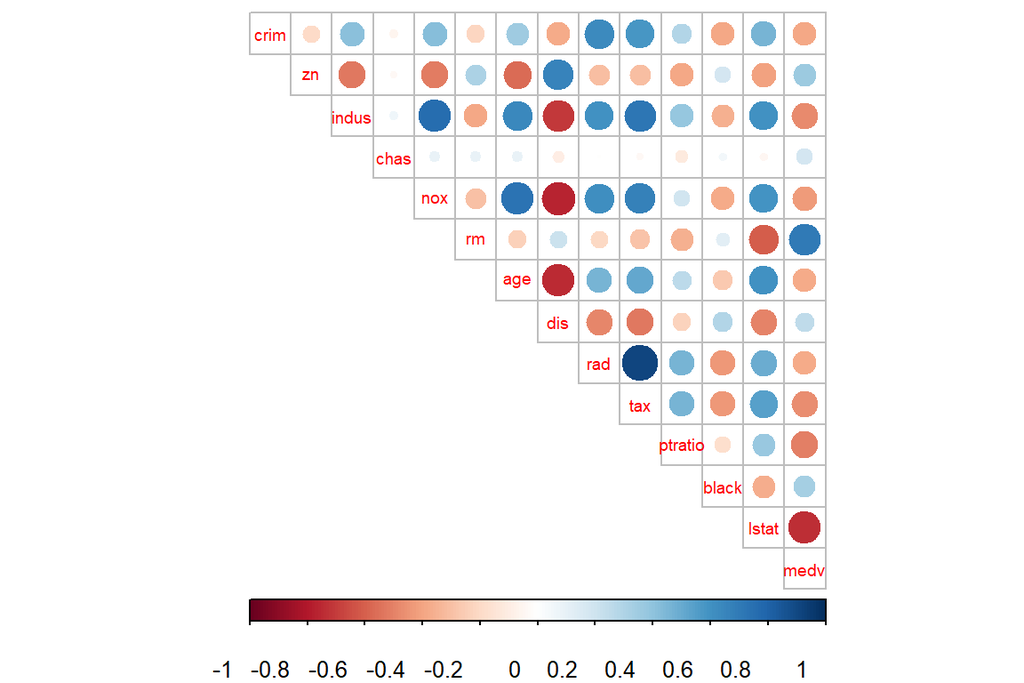

```r
# visualize the correlation matrix
corrplot(cor_matrix, method="circle", type="upper", cl.pos="b", tl.pos="d", tl.cex = 0.6)
```

```r
#compute summary statistics
summary(Boston)
```

```
##       crim                zn             indus            chas
##  Min.   : 0.00632   Min.   :  0.00   Min.   : 0.46   Min.   :0.00000
##  1st Qu.: 0.08205   1st Qu.:  0.00   1st Qu.: 5.19   1st Qu.:0.00000
##  Median : 0.25651   Median :  0.00   Median : 9.69   Median :0.00000
##  Mean   : 3.61352   Mean   : 11.36   Mean   :11.14   Mean   :0.06917
##  3rd Qu.: 3.67708   3rd Qu.: 12.50   3rd Qu.:18.10   3rd Qu.:0.00000
##  Max.   :88.97620   Max.   :100.00   Max.   :27.74   Max.   :1.00000
##       nox               rm             age              dis
##  Min.   :0.3850   Min.   :3.561   Min.   :  2.90   Min.   : 1.130
##  1st Qu.:0.4490   1st Qu.:5.886   1st Qu.: 45.02   1st Qu.: 2.100
##  Median :0.5380   Median :6.208   Median : 77.50   Median : 3.207
##  Mean   :0.5547   Mean   :6.285   Mean   : 68.57   Mean   : 3.795
##  3rd Qu.:0.6240   3rd Qu.:6.623   3rd Qu.: 94.08   3rd Qu.: 5.188
##  Max.   :0.8710   Max.   :8.780   Max.   :100.00   Max.   :12.127
##       rad              tax           ptratio          black
##  Min.   : 1.000   Min.   :187.0   Min.   :12.60   Min.   :  0.32
##  1st Qu.: 4.000   1st Qu.:279.0   1st Qu.:17.40   1st Qu.:375.38
##  Median : 5.000   Median :330.0   Median :19.05   Median :391.44
##  Mean   : 9.549   Mean   :408.2   Mean   :18.46   Mean   :356.67
##  3rd Qu.:24.000   3rd Qu.:666.0   3rd Qu.:20.20   3rd Qu.:396.23
##  Max.   :24.000   Max.   :711.0   Max.   :22.00   Max.   :396.90
##      lstat            medv
##  Min.   : 1.73   Min.   : 5.00
##  1st Qu.: 6.95   1st Qu.:17.02
##  Median :11.36   Median :21.20
##  Mean   :12.65   Mean   :22.53
##  3rd Qu.:16.95   3rd Qu.:25.00
##  Max.   :37.97   Max.   :50.00
```

**Exercise 4**  
Here I standardize the whole dataset. As we see in the summary statistics of the variables, the means are set to zero.

```r
boston_scaled <- scale(Boston) #standardize the dataset
summary(boston_scaled)
```

```
##       crim                 zn               indus              chas
##  Min.   :-0.419367   Min.   :-0.48724   Min.   :-1.5563   Min.   :-0.2723
##  1st Qu.:-0.410563   1st Qu.:-0.48724   1st Qu.:-0.8668   1st Qu.:-0.2723
##  Median :-0.390280   Median :-0.48724   Median :-0.2109   Median :-0.2723
##  Mean   : 0.000000   Mean   : 0.00000   Mean   : 0.0000   Mean   : 0.0000
##  3rd Qu.: 0.007389   3rd Qu.: 0.04872   3rd Qu.: 1.0150   3rd Qu.:-0.2723
##  Max.   : 9.924110   Max.   : 3.80047   Max.   : 2.4202   Max.   : 3.6648
##       nox                rm               age               dis
##  Min.   :-1.4644   Min.   :-3.8764   Min.   :-2.3331   Min.   :-1.2658
##  1st Qu.:-0.9121   1st Qu.:-0.5681   1st Qu.:-0.8366   1st Qu.:-0.8049
##  Median :-0.1441   Median :-0.1084   Median : 0.3171   Median :-0.2790
##  Mean   : 0.0000   Mean   : 0.0000   Mean   : 0.0000   Mean   : 0.0000
##  3rd Qu.: 0.5981   3rd Qu.: 0.4823   3rd Qu.: 0.9059   3rd Qu.: 0.6617
##  Max.   : 2.7296   Max.   : 3.5515   Max.   : 1.1164   Max.   : 3.9566
##       rad               tax             ptratio            black
##  Min.   :-0.9819   Min.   :-1.3127   Min.   :-2.7047   Min.   :-3.9033
##  1st Qu.:-0.6373   1st Qu.:-0.7668   1st Qu.:-0.4876   1st Qu.: 0.2049
##  Median :-0.5225   Median :-0.4642   Median : 0.2746   Median : 0.3808
##  Mean   : 0.0000   Mean   : 0.0000   Mean   : 0.0000   Mean   : 0.0000
##  3rd Qu.: 1.6596   3rd Qu.: 1.5294   3rd Qu.: 0.8058   3rd Qu.: 0.4332
##  Max.   : 1.6596   Max.   : 1.7964   Max.   : 1.6372   Max.   : 0.4406
##      lstat              medv
##  Min.   :-1.5296   Min.   :-1.9063
##  1st Qu.:-0.7986   1st Qu.:-0.5989
##  Median :-0.1811   Median :-0.1449
##  Mean   : 0.0000   Mean   : 0.0000
##  3rd Qu.: 0.6024   3rd Qu.: 0.2683
##  Max.   : 3.5453   Max.   : 2.9865
```

```r
boston_scaled <- as.data.frame(boston_scaled) #change the type
```

Then, I create a categorical variable of the crime rate in the Boston dataset, with low, medium low, medium high, and high categories included and replace the old crime rate variable with this one.

```r
# create a quantile vector of crim and print it
bins <- quantile(boston_scaled$crim)
bins
```

```
##           0%          25%          50%          75%         100%
## -0.419366929 -0.410563278 -0.390280295  0.007389247  9.924109610
```

```r
# create a categorical variable 'crime'
crime <- cut(boston_scaled$crim, breaks = bins, include.lowest = TRUE, label = c("low", "med_low", "med_high", "high"))

# look at the table of the new factor crime
table(crime)
```

```
## crime
##      low  med_low med_high     high
##      127      126      126      127
```

```r
# remove original crim from the dataset
boston_scaled <- dplyr::select(boston_scaled, -crim)

# add the new categorical value to scaled data
boston_scaled <- data.frame(boston_scaled, crime)
```

Last, I divide the dataset to train and test sets.

```r
# number of rows in the Boston dataset
n <- nrow(boston_scaled)

# choose randomly 80% of the rows
ind <- sample(n,  size = n * 0.8)

# create train set
train <- boston_scaled[ind,]

# create test set
test <- boston_scaled[-ind,]
```

**Exercise 5**  
Next, I fit a linear discriminant analysis on the train. In the model, categorical crime rate is predicted by all the other variables in the dataset.

```r
# linear discriminant analysis
lda.fit <- lda(crime ~ ., data = train)
lda.fit
```

```
## Call:
## lda(crime ~ ., data = train)
##
## Prior probabilities of groups:
##       low   med_low  med_high      high
## 0.2450495 0.2623762 0.2475248 0.2450495
##
## Group means:
##                   zn      indus        chas        nox          rm        age
## low       0.97686244 -0.9235781 -0.07348562 -0.8547773  0.45504035 -0.9001980
## med_low  -0.06130033 -0.3343639 -0.04947434 -0.5932391 -0.11394387 -0.4175039
## med_high -0.39977083  0.2032288  0.16075196  0.3771645  0.02730593  0.3948685
## high     -0.48724019  1.0171737 -0.07348562  1.0418675 -0.46665074  0.8510615
##                 dis        rad        tax     ptratio      black       lstat
## low       0.8727039 -0.6999747 -0.7295985 -0.39984129  0.3804490 -0.80060992
## med_low   0.3969462 -0.5441536 -0.4831889 -0.06835573  0.3225401 -0.16944881
## med_high -0.3501416 -0.4363494 -0.3169459 -0.17346099  0.1205486  0.07454589
## high     -0.8839563  1.6375616  1.5136504  0.78011702 -0.8719653  0.95381901
##                  medv
## low       0.535579405
## med_low   0.005459604
## med_high  0.116362027
## high     -0.680108487
##
## Coefficients of linear discriminants:
##                   LD1         LD2         LD3
## zn       0.1184719475  0.73315958 -1.00756033
## indus    0.0284287338 -0.35470478  0.35674941
## chas     0.0005912269 -0.01664219  0.04698150
## nox      0.3222480231 -0.72101284 -1.51097665
## rm       0.0118196183 -0.07203455 -0.16354627
## age      0.2596047996 -0.28803150 -0.15073933
## dis     -0.1088714401 -0.36109515  0.17384671
## rad      3.3725052477  0.90639410  0.06391078
## tax      0.0203622213  0.06765612  0.53948904
## ptratio  0.1320541657 -0.02589971 -0.47540016
## black   -0.1137927714  0.01235588  0.11606335
## lstat    0.2315742376 -0.29727180  0.32184228
## medv     0.0900997793 -0.44947294 -0.26101381
##
## Proportion of trace:
##    LD1    LD2    LD3
## 0.9533 0.0338 0.0129
```

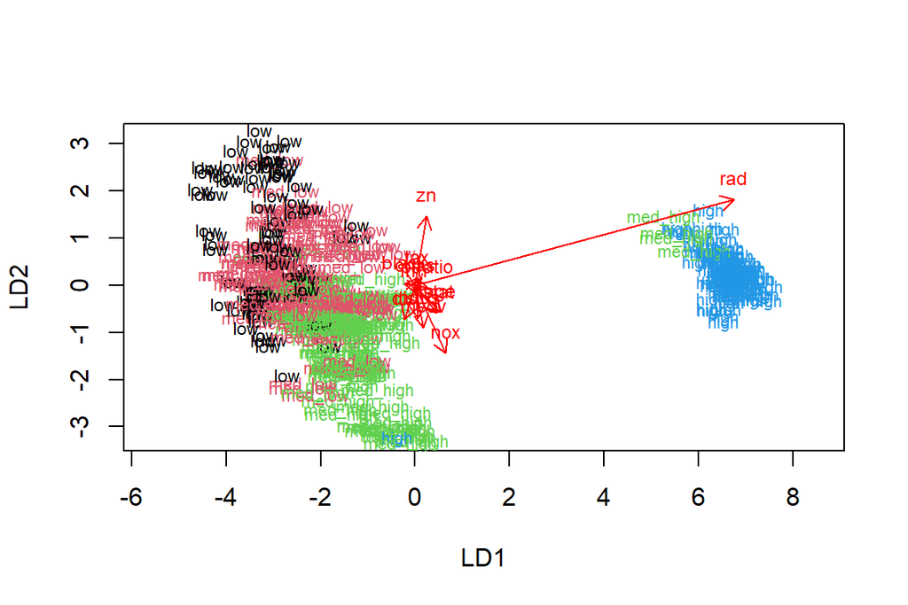

```
## integer(0)
```

```r
# the function for lda biplot arrows
lda.arrows <- function(x, myscale = 1, arrow_heads = 0.1, color = "red", tex = 0.75, choices = c(1,2)){
  heads <- coef(x)
  arrows(x0 = 0, y0 = 0,
         x1 = myscale * heads[,choices[1]],
         y1 = myscale * heads[,choices[2]], col=color, length = arrow_heads)
  text(myscale * heads[,choices], labels = row.names(heads),
       cex = tex, col=color, pos=3)
}

# target classes as numeric
classes <- as.numeric(train$crime)

# plot the lda results
plot(lda.fit, dimen = 2, col = classes, pch = classes) + lda.arrows(lda.fit, myscale = 2)
```

**Exercise 6**  
First, I save the crime classes from the test dataset and then modify the dataset by removing the classes. This is done to see how the LDA model performs in predicting the classes. The cross tabulation clearly shows that the classifier does good job in predicting crime rates: it mostly predicts the correct classes and most of the incorrect predictions are neighboring classes.

```r
# save the correct classes from test data
correct_classes <- test$crime

# remove the crime variable from test data
test <- dplyr::select(test, -crime)

# predict classes with test data
lda.pred <- predict(lda.fit, newdata = test)

# cross tabulate the results
table(correct = correct_classes, predicted = lda.pred$class)
```

```
##           predicted
## correct    low med_low med_high high
##   low       14      12        2    0
##   med_low    0      13        7    0
##   med_high   0       6       18    2
##   high       0       0        0   28
```

```r
#reload and standardize the Boston dataset
boston2 <- Boston
scaled2 <- scale(boston2)
scaled2 <- as.data.frame(boston2)

glimpse(dist(boston2)) #euclidean distances
```

```
##  'dist' num [1:127765] 59 58.5 79.3 78 76.8 ...
##  - attr(*, "Size")= int 506
##  - attr(*, "Labels")= chr [1:506] "1" "2" "3" "4" ...
##  - attr(*, "Diag")= logi FALSE
##  - attr(*, "Upper")= logi FALSE
##  - attr(*, "method")= chr "euclidean"
##  - attr(*, "call")= language dist(x = boston2)
```

First, I run a k-means clustering with a random number of centroids (3). Then I determine the optimal number of clusters using the total WCSS (within cluster sum of squares). In this case, the optimal number is two (see the first figure below). Last, I run the cluster analysis again with the optimal number of clusters determined. Scatter plots of the variables with the two clusters in black and red can be seen below.

It seems that most of the variables are somehow related to the clusters. For example, tax [full-value property-tax rate], ptratio [pupil-teacher ratio], rad [accessibility to radial highways], age [proportion of old buildings], and nox [air pollution] seem highly related to suburb cluster membership. Suburbs high in tax and with a certain, rather high ptratio belong to the red cluster regardless of the values of their neighboring variables. Suburbs with a greater age and an increased nox also tend to belong to the red cluster. Chas [does the tract bound the Charles River], in turn, was unrelated to the other variables in terms of correlation (see Exercise 3) and seems also unrelated to the clustering of the suburbs.

Altogether, one interpretation could be that the red cluster comprises of suburbs where most people live: not the downtowns, peripheral areas, or industrial estates with only few inhabitants, but the suburbs where most buildings are dwelling houses.

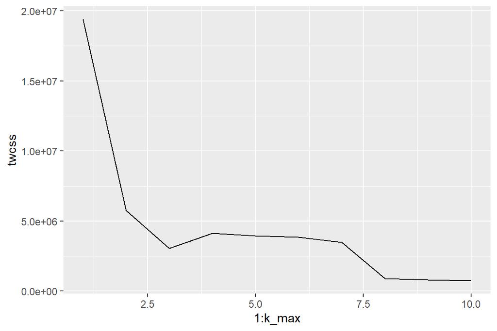

```r
# first k-means clustering with a random number of clusters
km <- kmeans(scaled2, centers = 3)

# set seed so that the results won't change
set.seed(123)

# determine the number of clusters
k_max <- 10

# calculate the total within sum of squares
twcss <- sapply(1:k_max, function(k){kmeans(scaled2, k)$tot.withinss})

# visualize the results
library(ggplot2)
qplot(x = 1:k_max, y = twcss, geom = 'line')
```

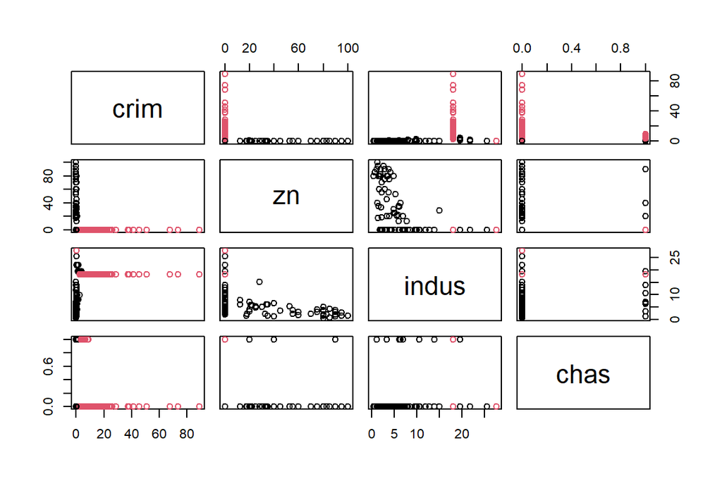

```r
# k-means clustering
km <- kmeans(scaled2, centers = 2)

# plot the Boston dataset with clusters
pairs(scaled2[1:4], col = km$cluster)
```

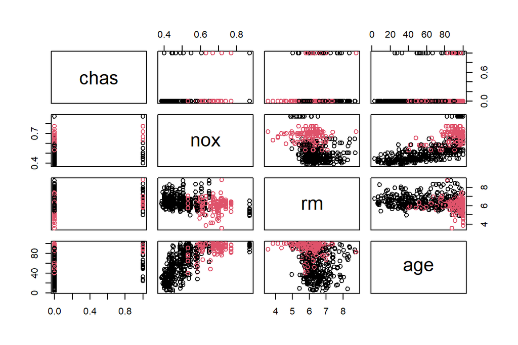

```r
pairs(scaled2[4:7], col = km$cluster)
```

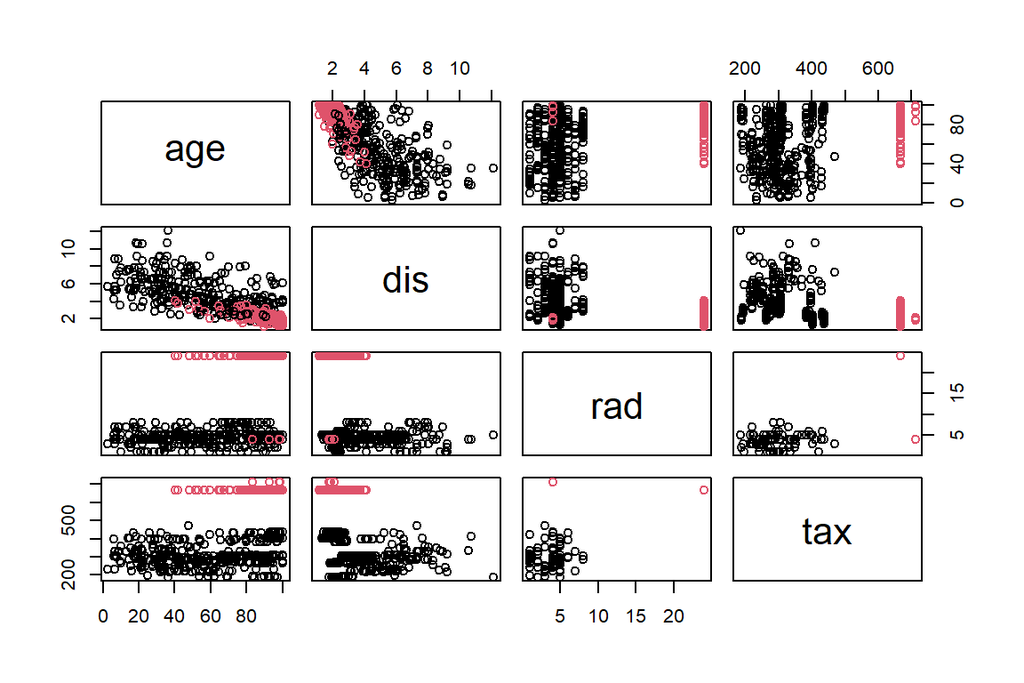

```r
pairs(scaled2[7:10], col = km$cluster)
```

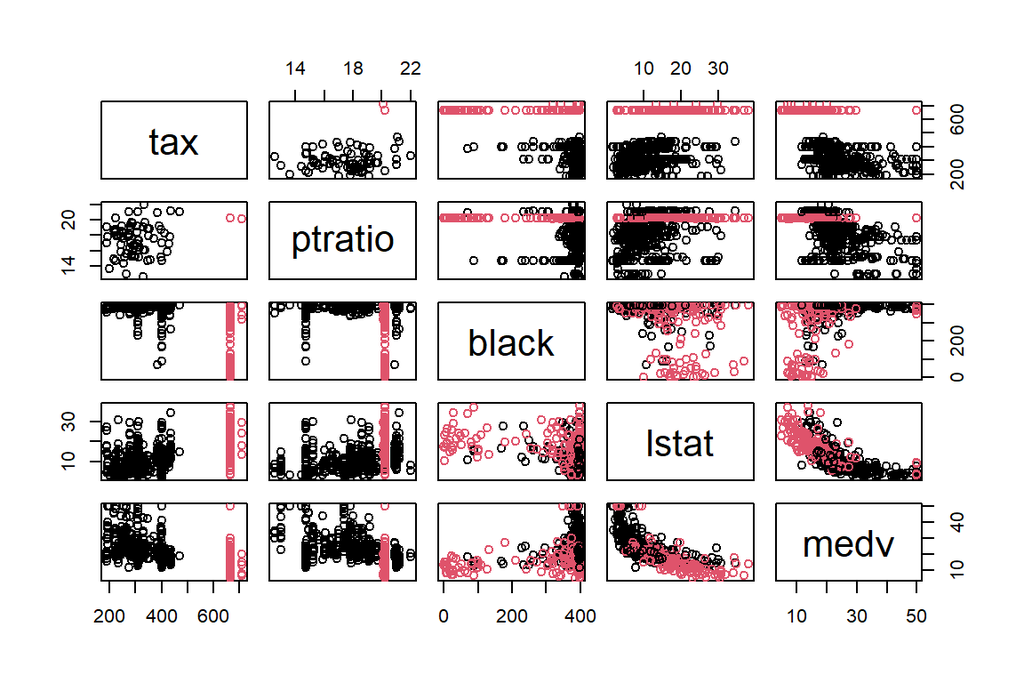

```r
pairs(scaled2[10:14], col = km$cluster)
```

# Week 5: Dimensionality reduction techniques

**Exercise 1**  
Here’s the human dataset I wrangled all by myself! As can be seen from the summary statistics of the variables, the range of values between the countries is huge. This, of course, is natural since all kinds of countries are included (n = 155).

Distributions of the variables along with scatter plots and correlation coefficients of each pair of variables are presented in the first plot. The second plot visualizes the correlations in another way: the larger the diameter of the dot, the stronger the correlation. Red implies a negative relationship between two variables, blue stands for a positive one.

```r
library(tidyverse)
```

```r
library(ggplot2)
library(GGally)
library(corrplot)
human4 <- read.csv("C:/LocalData/xpoxpox/IODS-project/data/human.csv", row.names = 1)
summary(human4)
```

```
##     ratio2ed         ratiolab         lifeexp          edexp
##  Min.   :0.1717   Min.   :0.1857   Min.   :49.00   Min.   : 5.40
##  1st Qu.:0.7264   1st Qu.:0.5984   1st Qu.:66.30   1st Qu.:11.25
##  Median :0.9375   Median :0.7535   Median :74.20   Median :13.50
##  Mean   :0.8529   Mean   :0.7074   Mean   :71.65   Mean   :13.18
##  3rd Qu.:0.9968   3rd Qu.:0.8535   3rd Qu.:77.25   3rd Qu.:15.20
##  Max.   :1.4967   Max.   :1.0380   Max.   :83.50   Max.   :20.20
##       gni            matdeath         teenmom          propparl
##  Min.   :   581   Min.   :   1.0   Min.   :  0.60   Min.   : 0.00
##  1st Qu.:  4198   1st Qu.:  11.5   1st Qu.: 12.65   1st Qu.:12.40
##  Median : 12040   Median :  49.0   Median : 33.60   Median :19.30
##  Mean   : 17628   Mean   : 149.1   Mean   : 47.16   Mean   :20.91
##  3rd Qu.: 24512   3rd Qu.: 190.0   3rd Qu.: 71.95   3rd Qu.:27.95
##  Max.   :123124   Max.   :1100.0   Max.   :204.80   Max.   :57.50
```

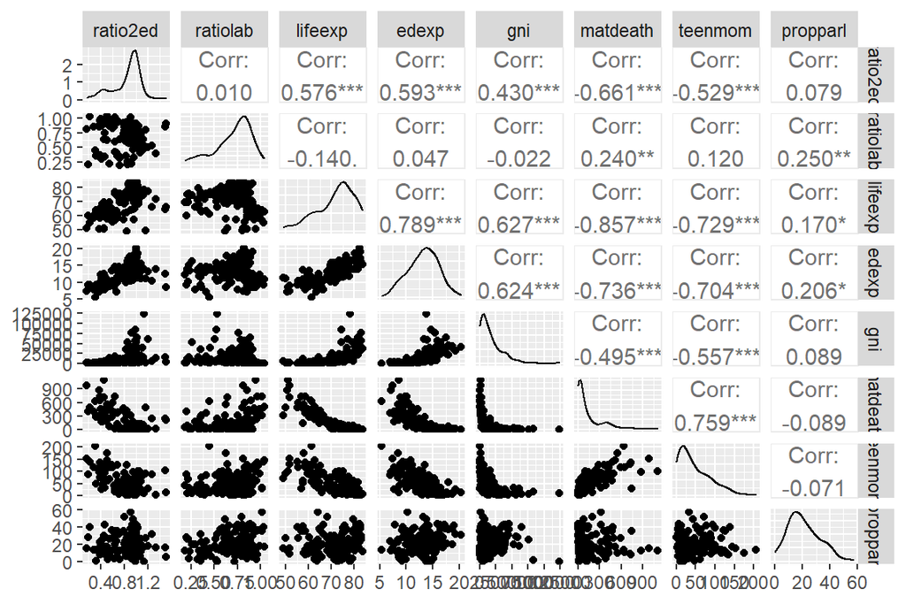

```r
ggpairs(human4)
```

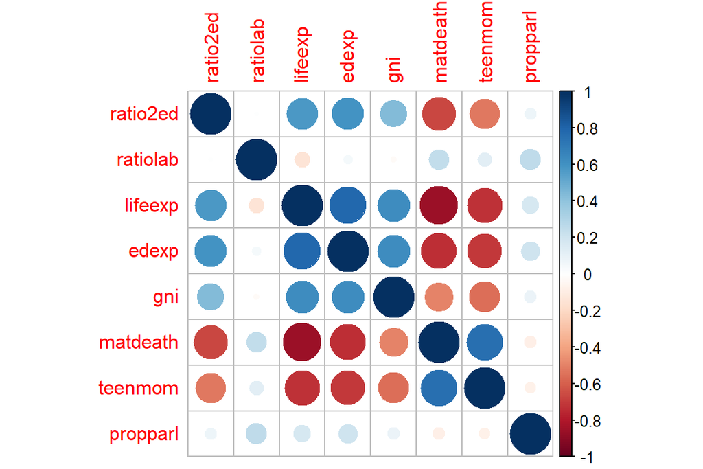

```r
cor(human4) %>%
  corrplot()
```

Next, I’ll perform principal component analysis (PCA) on the not standardized human data (Exercise 2) and the standardized human data (Exercise 3).

```r
# print out summaries of the variables
summary(human4)
```

```
##     ratio2ed         ratiolab         lifeexp          edexp
##  Min.   :0.1717   Min.   :0.1857   Min.   :49.00   Min.   : 5.40
##  1st Qu.:0.7264   1st Qu.:0.5984   1st Qu.:66.30   1st Qu.:11.25
##  Median :0.9375   Median :0.7535   Median :74.20   Median :13.50
##  Mean   :0.8529   Mean   :0.7074   Mean   :71.65   Mean   :13.18
##  3rd Qu.:0.9968   3rd Qu.:0.8535   3rd Qu.:77.25   3rd Qu.:15.20
##  Max.   :1.4967   Max.   :1.0380   Max.   :83.50   Max.   :20.20
##       gni            matdeath         teenmom          propparl
##  Min.   :   581   Min.   :   1.0   Min.   :  0.60   Min.   : 0.00
##  1st Qu.:  4198   1st Qu.:  11.5   1st Qu.: 12.65   1st Qu.:12.40
##  Median : 12040   Median :  49.0   Median : 33.60   Median :19.30
##  Mean   : 17628   Mean   : 149.1   Mean   : 47.16   Mean   :20.91
##  3rd Qu.: 24512   3rd Qu.: 190.0   3rd Qu.: 71.95   3rd Qu.:27.95
##  Max.   :123124   Max.   :1100.0   Max.   :204.80   Max.   :57.50
```

```r
# perform and save PCA
pca_human4_nonstd <- prcomp(human4)

# save and print out summary of the results
s_nonstd <- summary(pca_human4_nonstd)
s_nonstd
```

```
## Importance of components:
##                              PC1      PC2   PC3   PC4   PC5   PC6    PC7    PC8
## Standard deviation     1.854e+04 185.5219 25.19 11.45 3.766 1.566 0.1912 0.1591
## Proportion of Variance 9.999e-01   0.0001  0.00  0.00 0.000 0.000 0.0000 0.0000
## Cumulative Proportion  9.999e-01   1.0000  1.00  1.00 1.000 1.000 1.0000 1.0000
```

```r
# save and print out rounded percetanges of variance captured by each PC
pca_pr_nonstd <- round(100*s_nonstd$importance[2, ], digits = 1)
pca_pr_nonstd
```

```
## PC1 PC2 PC3 PC4 PC5 PC6 PC7 PC8
## 100   0   0   0   0   0   0   0
```

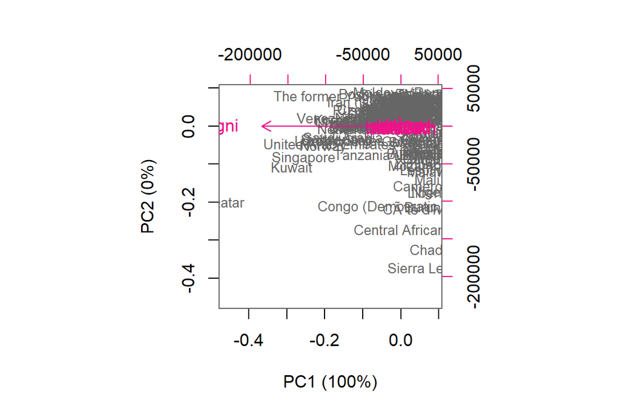

```r
# create object pc_lab to be used as axis labels
pc_lab_nonstd <- paste0(names(pca_pr_nonstd), " (", pca_pr_nonstd, "%)")

# draw a biplot
biplot(pca_human4_nonstd, cex = c(0.8, 1), col = c("grey40", "deeppink2"), xlab = pc_lab_nonstd[1], ylab = pc_lab_nonstd[2])
```

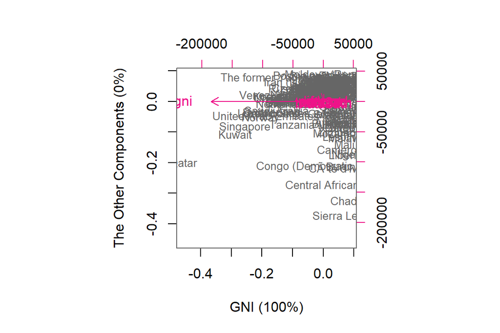

```r
# draw a biplot with names given to the components
biplot(pca_human4_nonstd, cex = c(0.8, 1), col = c("grey40", "deeppink2"), xlab = paste0("GNI", " (", pca_pr_nonstd[1], "%)"), ylab = paste0("The Other Components", " (", pca_pr_nonstd[2], "%)"))
```

```r
# stadardize human4
human4_std <- scale(human4)

# perform and save PCA
pca_human4_std <- prcomp(human4_std)

# save and print out summary of the results
s_std <- summary(pca_human4_std)
s_std
```

```
## Importance of components:
##                           PC1    PC2     PC3     PC4     PC5     PC6     PC7
## Standard deviation     2.0708 1.1397 0.87505 0.77886 0.66196 0.53631 0.45900
## Proportion of Variance 0.5361 0.1624 0.09571 0.07583 0.05477 0.03595 0.02634
## Cumulative Proportion  0.5361 0.6984 0.79413 0.86996 0.92473 0.96069 0.98702
##                            PC8
## Standard deviation     0.32224
## Proportion of Variance 0.01298
## Cumulative Proportion  1.00000
```

```r
# save and print out rounded percetanges of variance captured by each PC
pca_pr_std <- round(100*s_std$importance[2, ], digits = 1)
pca_pr_std
```

```
##  PC1  PC2  PC3  PC4  PC5  PC6  PC7  PC8
## 53.6 16.2  9.6  7.6  5.5  3.6  2.6  1.3
```

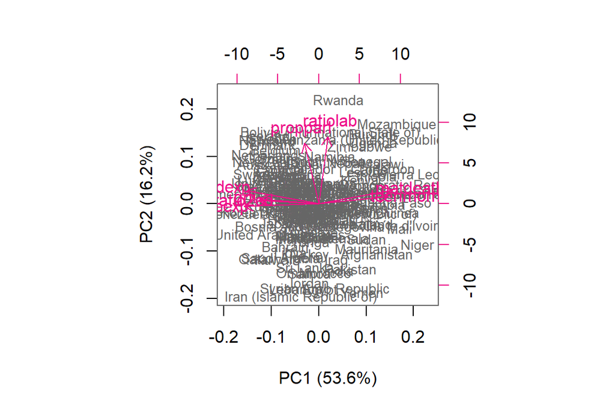

```r
# create object pc_lab to be used as axis labels
pc_lab_std <- paste0(names(pca_pr_std), " (", pca_pr_std, "%)")

# draw a biplot
biplot(pca_human4_std, cex = c(0.8, 1), col = c("grey40", "deeppink2"), xlab = pc_lab_std[1], ylab = pc_lab_std[2])
```

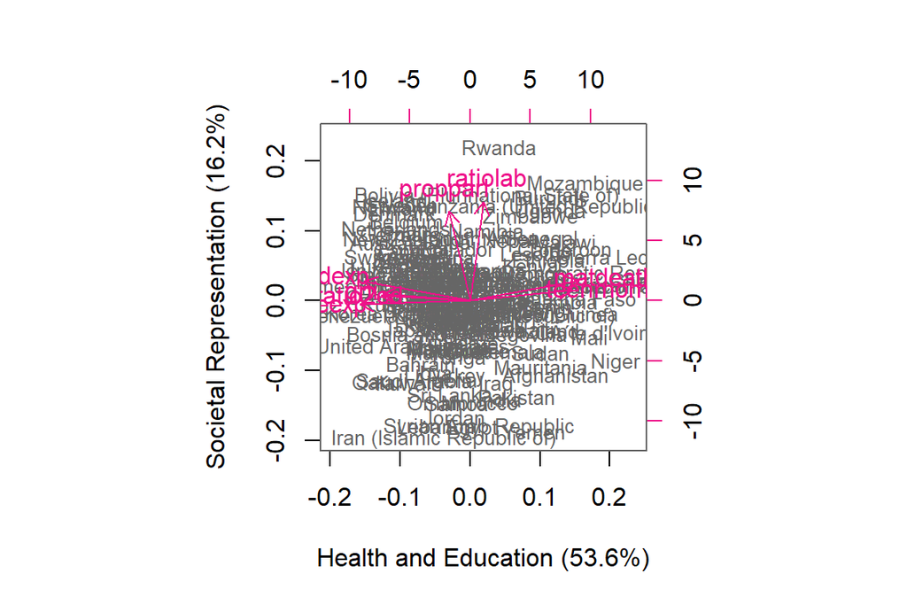

```r
# draw a biplot with names given to the components
biplot(pca_human4_std, cex = c(0.8, 1), col = c("grey40", "deeppink2"), xlab = paste0("Health and Education", " (", pca_pr_std[1], "%)"), ylab = paste0("Societal Representation", " (", pca_pr_std[2], "%)"))
```

**Exercise 4**  
As stated in Exercise 3, I named the two principal component dimensions extracted in the PCA “Health and Education” (~54%) and “Societal Representation” (~16%). The first dimension comprises of variables related to female life and educational expectancies and representation on the one hand, and factors related to reproduction on the other. The former is negatively related to the latter. Broadly, these variables are associated with general and female health and education, justifying the name “Health and Education”. The second dimension represents variables associated with the representation of women in society: their proportion in the labour force and parliament. Hence, this dimension was given the name “Societal Representation”.

**Exercise 5**  
The tea dataset from the FactoMineR package contains 300 observations of 36 variables related to different ways the participants consumed tea. Here, I focus on 6 of the variables and perform MCA on them: tea type (variable Tea), accompaniment (How), package (how), place of purchase (where), and consumption at lunch (lunch). Based on these observations, Earl Grey tea purchased from a chain store and extracted using a tea bag is consumed alone outside lunch time. Adding sugar to tea seems as common as not adding it.

```r
# getting required packages from library
library(FactoMineR)
```

```r
library(ggplot2)
library(tidyr)
library(dplyr)
```

```r
# load tea data
data(tea)

# look at the structure and dimensions of the data
dim(tea)
```

```
## [1] 300  36
```

```r
# column names to keep in a new dataset
keep_columns <- c("Tea", "How", "how", "sugar", "where", "lunch")

# select the 'keep_columns' to create the new dataset
tea_time <- dplyr::select(tea, one_of(keep_columns))

# look at the summaries and structure of the new dataset
summary(tea_time)
```

```
##         Tea         How                      how           sugar
##  black    : 74   alone:195   tea bag           :170   No.sugar:155
##  Earl Grey:193   lemon: 33   tea bag+unpackaged: 94   sugar   :145
##  green    : 33   milk : 63   unpackaged        : 36
##                  other:  9
##                   where           lunch
##  chain store         :192   lunch    : 44
##  chain store+tea shop: 78   Not.lunch:256
##  tea shop            : 30
##
```

```r
str(tea_time)
```

```
## 'data.frame':    300 obs. of  6 variables:
##  $ Tea  : Factor w/ 3 levels "black","Earl Grey",..: 1 1 2 2 2 2 2 1 2 1 ...
##  $ How  : Factor w/ 4 levels "alone","lemon",..: 1 3 1 1 1 1 1 3 3 1 ...
##  $ how  : Factor w/ 3 levels "tea bag","tea bag+unpackaged",..: 1 1 1 1 1 1 1 1 2 2 ...
##  $ sugar: Factor w/ 2 levels "No.sugar","sugar": 2 1 1 2 1 1 1 1 1 1 ...
##  $ where: Factor w/ 3 levels "chain store",..: 1 1 1 1 1 1 1 1 2 2 ...
##  $ lunch: Factor w/ 2 levels "lunch","Not.lunch": 2 2 2 2 2 2 2 2 2 2 ...
```

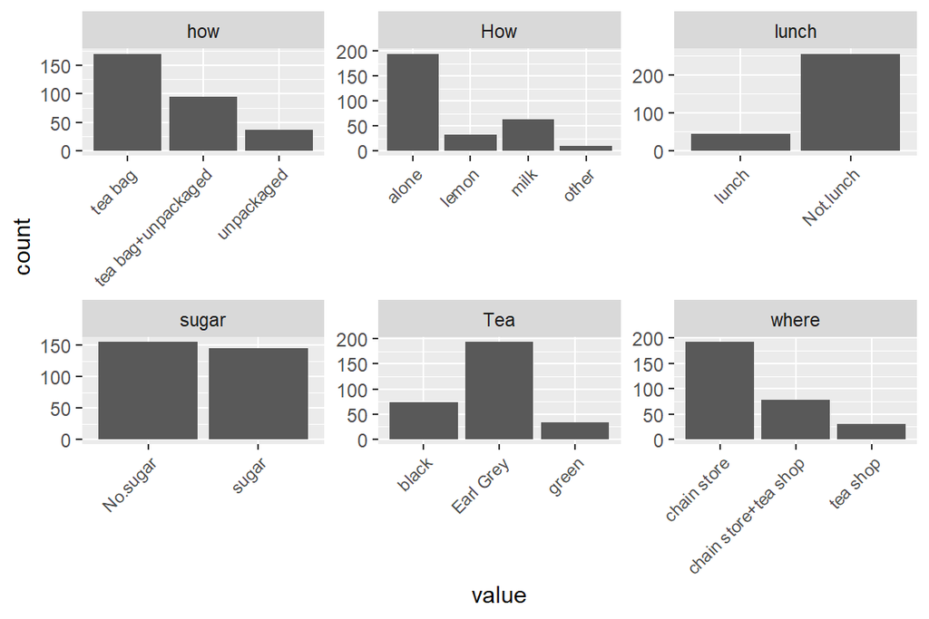

```r
# visualize the new dataset
gather(tea_time) %>% ggplot(aes(value)) + facet_wrap("key", scales = "free") + geom_bar() + theme(axis.text.x = element_text(angle = 45, hjust = 1, size = 8))
```

Here, a multiple correspondence analysis (MCA) is performed on selected variables of the tea data (see the description above). Based on the biplot, it seems that the first dimension captures variability in place of purchase and package: unpackaged tea is often bought from tea shops whereas packaged tea finds its way to tea cups from the shelves of chain stores. The other dimension (as I see it) could be associated with whether the individual is devoted to certain tea consumption habits: some buy tea from both chain stores and tea shops and drink it regardless of packaging, while others are more precise when it comes to details.

```r
# multiple correspondence analysis
mca <- MCA(tea_time, graph = FALSE)

# summary of the model
summary(mca)
```

```
##
## Call:
## MCA(X = tea_time, graph = FALSE)
##
##
## Eigenvalues
##                        Dim.1   Dim.2   Dim.3   Dim.4   Dim.5   Dim.6   Dim.7
## Variance               0.279   0.261   0.219   0.189   0.177   0.156   0.144
## % of var.             15.238  14.232  11.964  10.333   9.667   8.519   7.841
## Cumulative % of var.  15.238  29.471  41.435  51.768  61.434  69.953  77.794
##                        Dim.8   Dim.9  Dim.10  Dim.11
## Variance               0.141   0.117   0.087   0.062
## % of var.              7.705   6.392   4.724   3.385
## Cumulative % of var.  85.500  91.891  96.615 100.000
##
## Individuals (the 10 first)
##                       Dim.1    ctr   cos2    Dim.2    ctr   cos2    Dim.3
## 1                  | -0.298  0.106  0.086 | -0.328  0.137  0.105 | -0.327
## 2                  | -0.237  0.067  0.036 | -0.136  0.024  0.012 | -0.695
## 3                  | -0.369  0.162  0.231 | -0.300  0.115  0.153 | -0.202
## 4                  | -0.530  0.335  0.460 | -0.318  0.129  0.166 |  0.211
## 5                  | -0.369  0.162  0.231 | -0.300  0.115  0.153 | -0.202
## 6                  | -0.369  0.162  0.231 | -0.300  0.115  0.153 | -0.202
## 7                  | -0.369  0.162  0.231 | -0.300  0.115  0.153 | -0.202
## 8                  | -0.237  0.067  0.036 | -0.136  0.024  0.012 | -0.695
## 9                  |  0.143  0.024  0.012 |  0.871  0.969  0.435 | -0.067
## 10                 |  0.476  0.271  0.140 |  0.687  0.604  0.291 | -0.650
##                       ctr   cos2
## 1                   0.163  0.104 |
## 2                   0.735  0.314 |
## 3                   0.062  0.069 |
## 4                   0.068  0.073 |
## 5                   0.062  0.069 |
## 6                   0.062  0.069 |
## 7                   0.062  0.069 |
## 8                   0.735  0.314 |
## 9                   0.007  0.003 |
## 10                  0.643  0.261 |
##
## Categories (the 10 first)
```

[output cut: 16 more lines]

```
## lemon                3.226 |   1.329  14.771   0.218   8.081 |
## milk                 2.422 |   0.013   0.003   0.000   0.116 |
## other                5.534 |  -2.524  14.526   0.197  -7.676 |
## tea bag             -6.941 |  -0.065   0.183   0.006  -1.287 |
## tea bag+unpackaged  11.956 |   0.019   0.009   0.000   0.226 |
## unpackaged          -6.482 |   0.257   0.602   0.009   1.640 |
##
## Categorical variables (eta2)
##                      Dim.1 Dim.2 Dim.3
## Tea                | 0.126 0.108 0.410 |
## How                | 0.076 0.190 0.394 |
## how                | 0.708 0.522 0.010 |
## sugar              | 0.065 0.001 0.336 |
## where              | 0.702 0.681 0.055 |
## lunch              | 0.000 0.064 0.111 |
```

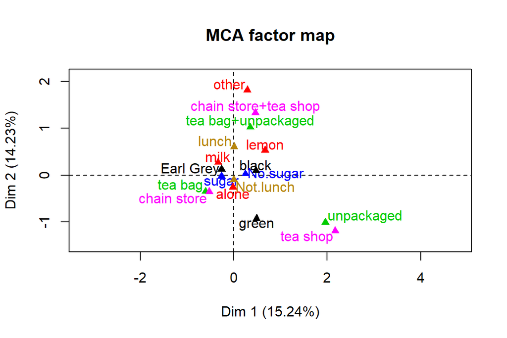

```r
# visualize MCA
plot(mca, invisible=c("ind"), habillage = "quali", graph.type = "classic")
```

# Week 6: Analysis of longitudinal data

**Exercise 1**

The RATS data are collected during a longitudinal experiment which focused on the effect of nutrition on weight trajectories of rats. The rats were assigned in three groups with different diets and each animal’s body weight was recorded weekly for nine weeks. The dataset has been wrangled into long form.

Let’s begin by reading the RATS (+L for long) dataset, changing the two categorical variables into factors, and removing the unneeded variable ‘WD’. Let’s also take a look at the first rows of the data.

```r
RATSL <- read.csv("C:/LocalData/xpoxpox/IODS-project/data/ratsl.csv")
RATSL$ID <- factor(RATSL$ID)
RATSL$Group <- factor(RATSL$Group)
RATSL <- subset(RATSL, select = -c(WD))
head(RATSL)
```

```
##   ID Group Weight Time
## 1  1     1    240    1
## 2  2     1    225    1
## 3  3     1    245    1
## 4  4     1    260    1
## 5  5     1    255    1
## 6  6     1    260    1
```

In order to find out whether there are differences in weight trajectories between the three groups, let’s first visualize individual weight trajectories by diet. While the slopes seem to follow a similar, increasing trend across the groups, rats assigned to Groups 2 and 3 are much heavier at week 1 compared to Group 1 rats. On average, rats in Group 3 are slightly heavier at week 1 than those in Group 2. There is also an obvious outlier in Group 2, a rat that is even heavier at week 1 than the rats in Group 3.

What’s the point in comparing the effect of different diets if the groups differ radically already at the beginning? Just saying…

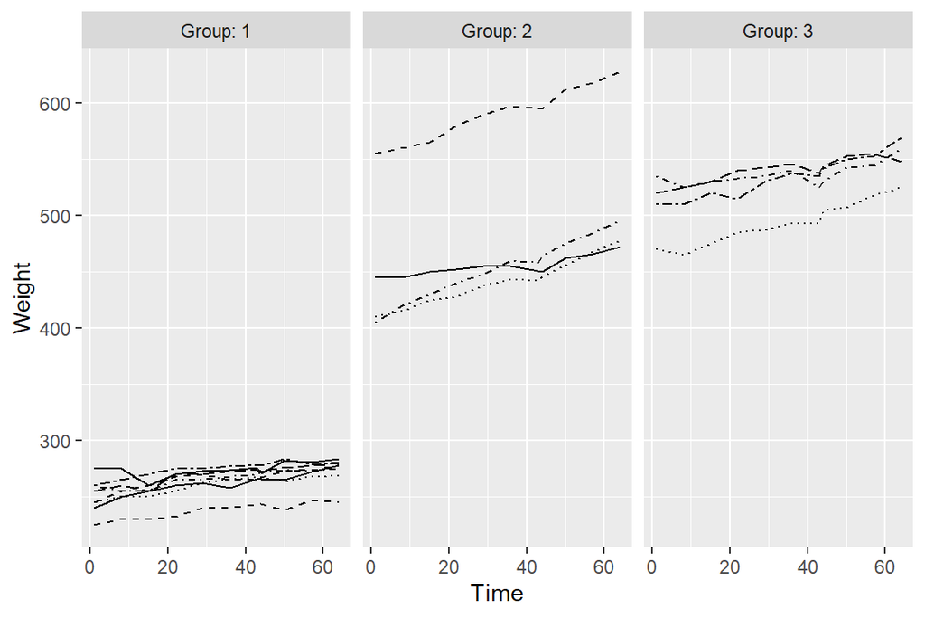

```r
#Access the package ggplot2
library(ggplot2)

# Draw the plot
ggplot(RATSL, aes(x = Time, y = Weight, linetype = ID)) +
  geom_line() +
  scale_linetype_manual(values = rep(1:10, times=4)) +
  facet_grid(. ~ Group, labeller = label_both) +
  theme(legend.position = "none") +
  scale_y_continuous(limits = c(min(RATSL$Weight), max(RATSL$Weight)))
```

Another perspective to individual weight trajectories by diet can be taken by visualizing the development of standardized weights of the rats across the 9 weeks. In the plot below, the standardized weights are calculated by subtracting the relevant occasion mean from the original observation and then dividing by the corresponding visit standard deviation. The plot, thus, presents each weight in relation to the other rats’ weights at that time point. The relative position of each trajectory seems to remain rather similar throughout the experiment.

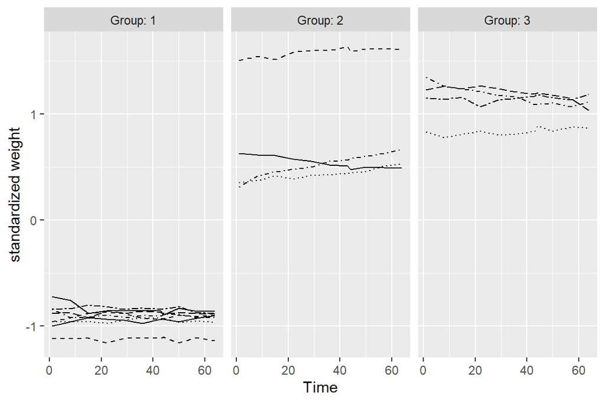

```r
#Standardise the variable Weight
RATSL <- RATSL %>%
  group_by(Time) %>%
  mutate(stdweight = (Weight - mean(Weight))/sd(Weight)) %>%
  ungroup()

#Plot again with the standardised weight
RATSL %>%
  ggplot(aes(x = Time, y = stdweight, linetype = ID)) +
  geom_line() +
  scale_linetype_manual(values = rep(1:10, times=4)) +
  facet_grid(. ~ Group, labeller = label_both) +
  theme(legend.position = "none") +
  scale_y_continuous(name = "standardized weight")
```

Similar to the individual trajectories of the rats, the overall trajectories of each group depict the difference in the intercepts of Group 1 and the other groups. The slopes, however, seem somewhat invariant across the groups, although weights of Group 1 rats seem most stable across time.

```r
# Number of rats per group:
n <- 4

# Summary data with mean and standard error of weight by group and time
RATSS <- RATSL %>%
  group_by(Group, Time) %>%
  summarise(mean = mean(Weight), se = sd(Weight)/sqrt(n)) %>%
  ungroup()
# Glimpse the data
glimpse(RATSS)
```

```
## Rows: 33
## Columns: 4
## $ Group <fct> 1, 1, 1, 1, 1, 1, 1, 1, 1, 1, 1, 2, 2, 2, 2, 2, 2, 2, 2, 2, 2, 2~
## $ Time  <int> 1, 8, 15, 22, 29, 36, 43, 44, 50, 57, 64, 1, 8, 15, 22, 29, 36, ~
## $ mean  <dbl> 250.625, 255.000, 254.375, 261.875, 264.625, 265.000, 267.375, 2~
## $ se    <dbl> 7.610789, 6.546537, 5.737953, 6.800407, 5.528740, 5.891883, 5.47~
```

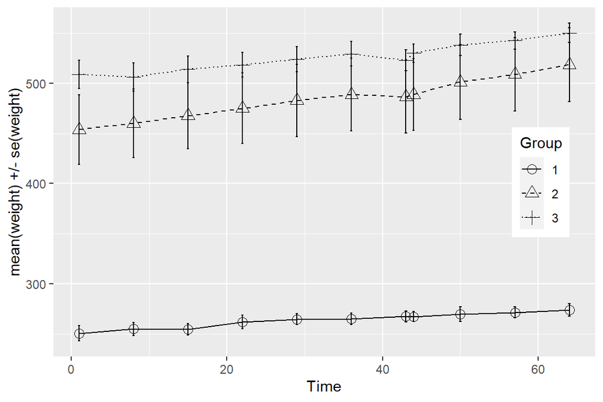

```r
# Plot the mean profiles
ggplot(RATSS, aes(x = Time, y = mean, linetype = Group, shape = Group)) +
  geom_line() +
  scale_linetype_manual(values = c(1,2,3)) +
  geom_point(size=3) +
  scale_shape_manual(values = c(1,2,3)) +
  geom_errorbar(aes(ymin = mean - se, ymax = mean + se, linetype="1"), width=0.3) +
  theme(legend.position = c(0.9,0.5)) +
  scale_y_continuous(name = "mean(weight) +/- se(weight)")
```

Now we’ll move on to comparing the average weight of rats in different groups across all time points (except week 1, which is considered as the baseline and used as an explanatory variable in subsequent analyses). Here are boxplots of mean summary measures for the three diet groups. As noted above, the first plot reveals an outlier in Group 2: a rat that is 100 grams heavier than the other rats in the group. After filtering out this rat, Group 2 boxplot becomes more similar to the other groups (with less variance within the group), demonstrating the substantial role one outlier can have when total number of subjects in a group is small.

```r
# Create a summary data by group and subject with mean as the summary variable (ignoring baseline week 1).
RATSL9w_sum <- RATSL %>%
  filter(Time > 1) %>%
  group_by(Group, ID) %>%
  summarise(mean = mean(Weight)) %>%
  ungroup()
# Glimpse the data
glimpse(RATSL9w_sum)
```

```
## Rows: 16
## Columns: 3
## $ Group <fct> 1, 1, 1, 1, 1, 1, 1, 1, 2, 2, 2, 2, 3, 3, 3, 3
## $ ID    <fct> 1, 2, 3, 4, 5, 6, 7, 8, 9, 10, 11, 12, 13, 14, 15, 16
## $ mean  <dbl> 263.2, 238.9, 261.7, 267.2, 270.9, 276.2, 274.6, 267.5, 443.9, 4~
```

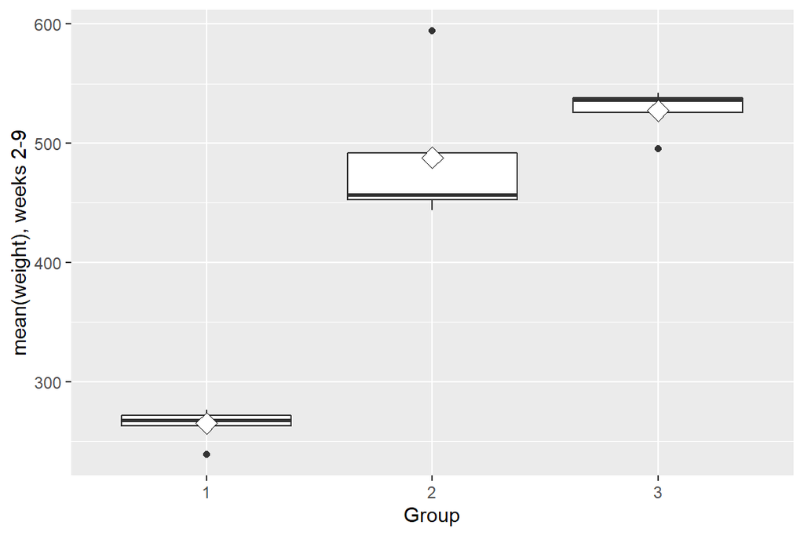

```r
# Draw a boxplot of the mean versus treatment
ggplot(RATSL9w_sum, aes(x = Group, y = mean)) +
  geom_boxplot() +
  stat_summary(fun.y = "mean", geom = "point", shape=23, size=4, fill = "white") +
  scale_y_continuous(name = "mean(weight), weeks 2-9")
```

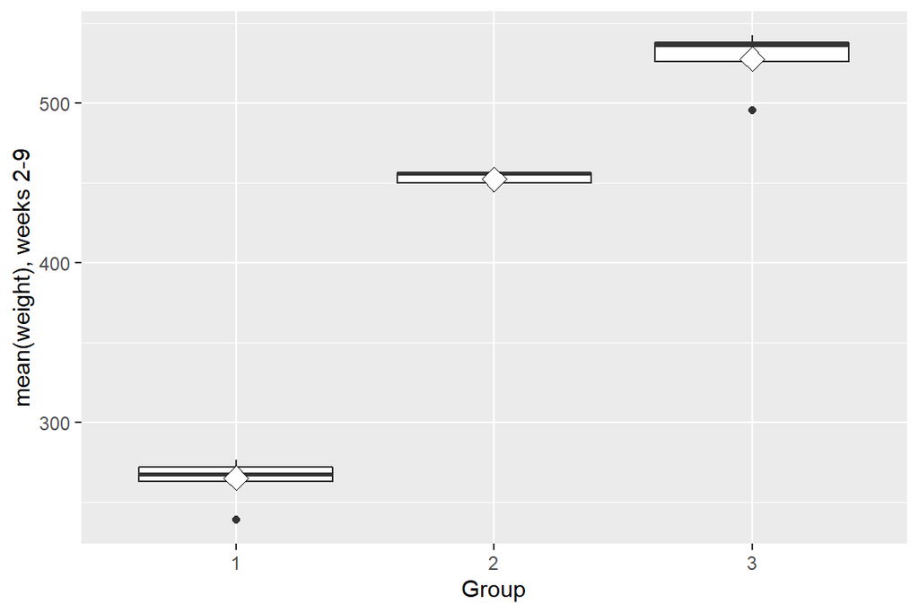

```r
# Create a new data by filtering the outlier and adjust the ggplot code the draw the plot again with the new data
RATSL9w_sum2 <- RATSL9w_sum %>%
  filter(mean < 550)

ggplot(RATSL9w_sum2, aes(x = Group, y = mean)) +
  geom_boxplot() +
  stat_summary(fun.y = "mean", geom = "point", shape=23, size=4, fill = "white") +
  scale_y_continuous(name = "mean(weight), weeks 2-9")
```

Last, let’s fit a linear model that predicts a rat’s average weight over an 8-week period by week 1 weight (baseline) and diet (Group). Let’s also conduct an analysis of variance (ANOVA; or is it ANCOVA in this case) to see whether diet (group membership) accounts for any variance between the groups when baseline weight has been controlled for.

As can be seen, baseline is the only significant component in both LM and ANCOVA. Regarding the LM, this means that baseline weight is a statistically significant predictor of mean weight while diet is not. The ANCOVA tells us that baseline weight is strongly related to mean weight but there is no evidence of a group difference after conditioning on the baseline weight.

```r
RATS <- read.csv("C:/LocalData/xpoxpox/IODS-project/data/rats.csv")

# Add the baseline from the original data as a new variable to the summary data
RATSL9w_sum3 <- RATSL9w_sum %>%
  mutate(baseline = RATS$WD1)

# Fit the linear model with the mean as the response
fit <- lm(mean ~ baseline + Group, data = RATSL9w_sum3)
summary(fit)
```

```
##
## Call:
## lm(formula = mean ~ baseline + Group, data = RATSL9w_sum3)
##
## Residuals:
##     Min      1Q  Median      3Q     Max
## -23.905  -4.194   2.190   7.577  14.800
##
## Coefficients:
##             Estimate Std. Error t value Pr(>|t|)
## (Intercept) 33.16375   21.87657   1.516   0.1554
## baseline     0.92513    0.08572  10.793 1.56e-07 ***
## Group2      34.85753   18.82308   1.852   0.0888 .
## Group3      23.67526   23.25324   1.018   0.3287
## ---
## Signif. codes:  0 '***' 0.001 '**' 0.01 '*' 0.05 '.' 0.1 ' ' 1
##
## Residual standard error: 11.68 on 12 degrees of freedom
## Multiple R-squared:  0.9936, Adjusted R-squared:  0.992
## F-statistic: 622.1 on 3 and 12 DF,  p-value: 1.989e-13
```

```r
# Compute the analysis of (co?)variance table for the fitted model with anova()
anova(fit)
```

```
## Analysis of Variance Table
##
## Response: mean
##           Df Sum Sq Mean Sq   F value   Pr(>F)
## baseline   1 253625  253625 1859.8201 1.57e-14 ***
## Group      2    879     439    3.2219  0.07586 .
## Residuals 12   1636     136
## ---
## Signif. codes:  0 '***' 0.001 '**' 0.01 '*' 0.05 '.' 0.1 ' ' 1
```

**Exercise 2**  
The BPRS dataset comprises of 40 subjects who were suspected of having schizophrenia. The subjects were divided into two treatment groups and their behavior was evaluated before the treatment began and weekly during the two-month treatment using the brief psychiatric rating scale (BPRS). In the BPRS, 18 symptom constructs, such as hostility, suspiciousness, hallucinations, and grandiosity, are rated from 1-7 to form an overall score. The dataset has already been wrangled into long form.

Let’s begin by reading the BPRS (+L for long) dataset, changing the two categorical variables into factors, and removing the unneeded variable ‘weeks’. Let’s also take a look at the first couple rows of the data.

```r
BPRSL <- read.csv("C:/LocalData/xpoxpox/IODS-project/data/bprsl.csv")
BPRSL$treatment <- factor(BPRSL$treatment)
BPRSL$subject <- factor(BPRSL$subject)
BPRSL <- subset(BPRSL, select = -c(weeks))
head(BPRSL)
```

```
##   treatment subject bprs week
## 1         1       1   42    0
## 2         1       2   58    0
## 3         1       3   54    0
## 4         1       4   55    0
## 5         1       5   72    0
## 6         1       6   48    0
```

Then it’s time to plot individual bprs growth trajectories! Oh, wait… What’s going on here? Why does the code work for the RATSL data but not the BPRSL data?

BPRSL (this is what came out):

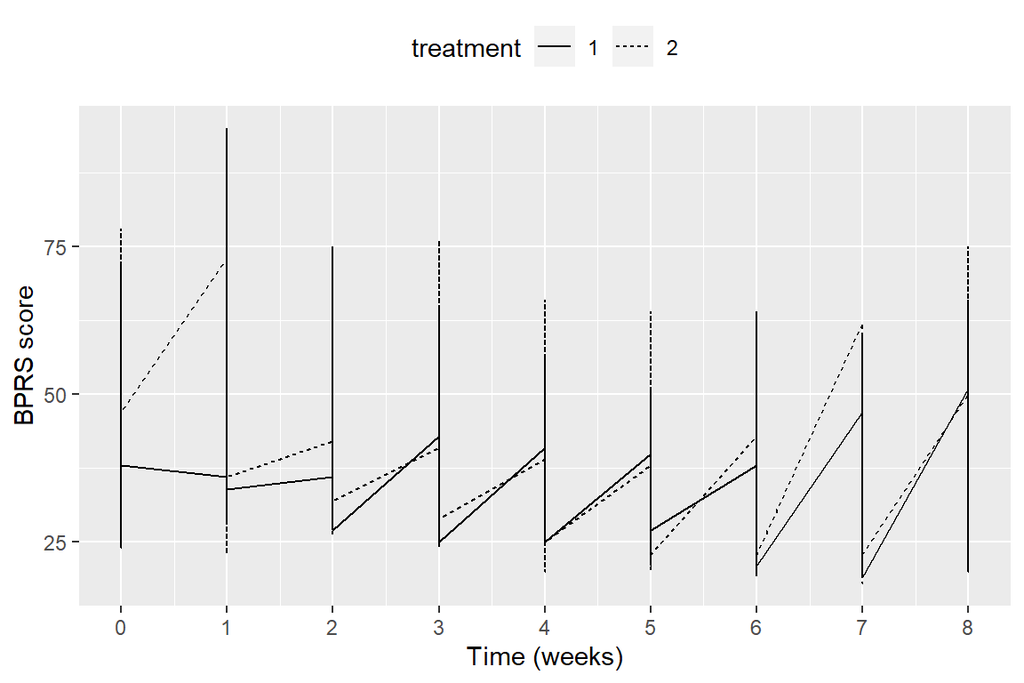

```r
# Plot the BPRSL data
ggplot(BPRSL, aes(x = week, y = bprs)) +
geom_line(aes(linetype = treatment)) +
scale_x_continuous(name = "Time (weeks)", breaks = seq(0, 8, 1)) +
scale_y_continuous(name = "BPRS score") +
theme(legend.position = "top")
```

RATSL (this is what the plot should look like):

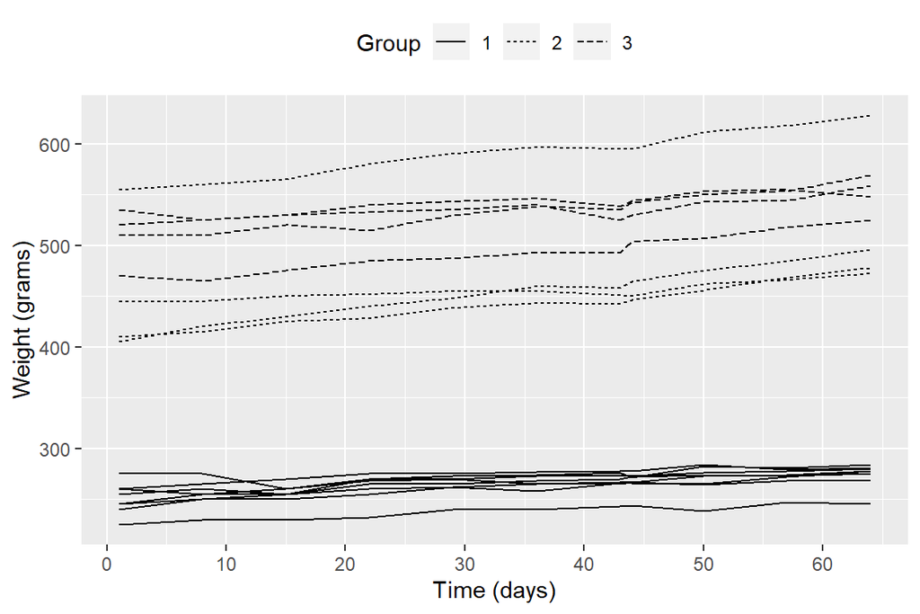

```r
ggplot(RATSL, aes(x = Time, y = Weight, group = ID)) +
  geom_line(aes(linetype = Group)) +
  scale_x_continuous(name = "Time (days)", breaks = seq(0, 60, 10)) +
  scale_y_continuous(name = "Weight (grams)") +
  theme(legend.position = "top")
```

It took a while but I eventually noticed that there is a difference in how the subjects are coded in the two datasets. In BPRSL, there are 40 subjects in total, 20 in each of the two treatment conditions. Subject IDs range from 1 to 20 in each condition, which means that there are no unique IDs for each subject but IDs 1-20 in both treatment groups. In RATSL, there are 16 rats in total and each has a unique ID. First eight belong to the first group, and the rest to two equally sized groups (4 rats in each).

```r
BPRSL %>% dplyr::select(subject, treatment) %>% head(n = 40)
```

```
##    subject treatment
## 1        1         1
## 2        2         1
## 3        3         1
## 4        4         1
## 5        5         1
## 6        6         1
## 7        7         1
## 8        8         1
## 9        9         1
## 10      10         1
## 11      11         1
## 12      12         1
## 13      13         1
## 14      14         1
```

[output cut: 26 more lines]

```r
RATSL %>% dplyr::select(ID, Group) %>% head(n = 16)
```

```
## # A tibble: 16 x 2
##    ID    Group
##    <fct> <fct>
##  1 1     1
##  2 2     1
##  3 3     1
##  4 4     1
##  5 5     1
##  6 6     1
##  7 7     1
##  8 8     1
##  9 9     2
## 10 10    2
## 11 11    2
## 12 12    2
## 13 13    3
## 14 14    3
## 15 15    3
## 16 16    3
```

Let us now code similar unique IDs for the subjects in BPRSL as we have for the rats in RATSL. Since I’m not a pro R wrangler, I have to create the IDs (variable ‘subject’) to the plain BPRS data and then perform all the data wrangling again. Luckily it’s easy to copy-paste so this didn’t take much time.

```r
BPRS <- read.csv("C:/LocalData/xpoxpox/IODS-project/data/bprs.csv")

#add IDs utilizing row numbers
BPRS$subject <- seq.int(nrow(BPRS))

#wrangle again: from wide to long, mutate variables etc.
BPRSL2 <-  BPRS %>%
  gather(key = weeks, value = bprs, -treatment, -subject)
BPRSL2 <- BPRSL2 %>%
  mutate(week = as.integer(substr(weeks,5,5)))
BPRSL2$treatment <- factor(BPRSL2$treatment)
BPRSL2$subject <- factor(BPRSL2$subject)
BPRSL2 <- subset(BPRSL2, select = -c(weeks))

#look at the data
BPRSL2 %>% dplyr::select(subject, treatment) %>% head(n = 40)
```

```
##    subject treatment
## 1        1         1
## 2        2         1
## 3        3         1
## 4        4         1
## 5        5         1
## 6        6         1
## 7        7         1
## 8        8         1
## 9        9         1
## 10      10         1
## 11      11         1
## 12      12         1
## 13      13         1
## 14      14         1
```

[output cut: 26 more lines]

Wow I’m so proud of myself! I figured out what’s going on and solved the problemos! What a way to spend one’s Saturday night. So, finally, here’s a plot that shows the individual bprs trajectories by treatment condition. It’s quite difficult to interpret the plot since there are so many lines. There seems to be a slightly decreasing trend over time but that’s all I can say at this point. Let’s see what the next plots and analyses tell us!

```r
# Check the dimensions of the data
dim(BPRSL2)
```

```
## [1] 360   4
```

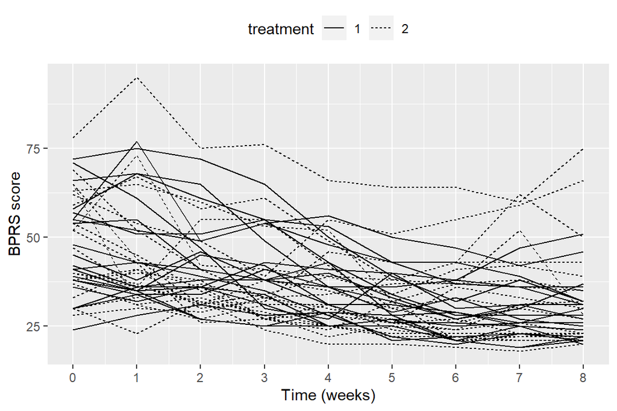

```r
# Plot the BPRSL data
ggplot(BPRSL2, aes(x = week, y = bprs, group = subject)) +
  geom_line(aes(linetype = treatment)) +
  scale_x_continuous(name = "Time (weeks)", breaks = seq(0, 8, 1)) +
  scale_y_continuous(name = "BPRS score") +
  theme(legend.position = "top")
```

Let’s now fit a linear regression model to BPRSL2 data with BPRS score as the response variable, and treatment group and week as explanatory variables (ignoring the repeated-measures structure of the data).

In the fitted model, the explanatory variables explain 18% of the variation in BPRS score, but only week is a statistically significant predictor while treatment is not. As the estimate of week is negative, BPRS score tends to decrease as weeks pass (by ~2.3 each week).

```r
# create a regression model BPRSL2_reg
BPRSL2_reg <- lm(bprs ~ week + treatment, data = BPRSL2)

# print out a summary of the model
summary(BPRSL2_reg)
```

```
##
## Call:
## lm(formula = bprs ~ week + treatment, data = BPRSL2)
##
## Residuals:
##     Min      1Q  Median      3Q     Max
## -22.454  -8.965  -3.196   7.002  50.244
##
## Coefficients:
##             Estimate Std. Error t value Pr(>|t|)
## (Intercept)  46.4539     1.3670  33.982   <2e-16 ***
## week         -2.2704     0.2524  -8.995   <2e-16 ***
## treatment2    0.5722     1.3034   0.439    0.661
## ---
## Signif. codes:  0 '***' 0.001 '**' 0.01 '*' 0.05 '.' 0.1 ' ' 1
##
## Residual standard error: 12.37 on 357 degrees of freedom
## Multiple R-squared:  0.1851, Adjusted R-squared:  0.1806
## F-statistic: 40.55 on 2 and 357 DF,  p-value: < 2.2e-16
```

The previous model assumes independence of the repeated measures of bprs, but this assumption is unlikely to hold. Here, we will fit a random intercept model which allows the linear regression fit for each rat to differ from other rats in intercept but not in slope. This model is fitted with the same explanatory variables for BPRS score as in the previous one, week and treatment.

```r
# access library lme4
library(lme4)
# Create a random intercept model
BPRSL2_ref <- lmer(bprs ~ week + treatment + (1 | subject), data = BPRSL2, REML = FALSE)

# Print the summary of the model
summary(BPRSL2_ref)
```

```
## Linear mixed model fit by maximum likelihood  ['lmerMod']
## Formula: bprs ~ week + treatment + (1 | subject)
##    Data: BPRSL2
##
##      AIC      BIC   logLik deviance df.resid
##   2582.9   2602.3  -1286.5   2572.9      355
##
## Scaled residuals:
##      Min       1Q   Median       3Q      Max
## -2.27506 -0.59909 -0.06104  0.44226  3.15835
##
## Random effects:
##  Groups   Name        Variance Std.Dev.
##  subject  (Intercept) 97.39    9.869
##  Residual             54.23    7.364
## Number of obs: 360, groups:  subject, 40
##
## Fixed effects:
##             Estimate Std. Error t value
## (Intercept)  46.4539     2.3521  19.750
## week         -2.2704     0.1503 -15.104
## treatment2    0.5722     3.2159   0.178
##
## Correlation of Fixed Effects:
##            (Intr) week
## week       -0.256
## treatment2 -0.684  0.000
```

In the next model, the random intercept and random slope model, linear regression fits for each individual are allowed to differ in intercept but also in slope. This way it is possible to account for the individual differences in the bprs growth trajectories, but also the effect of time. When comparing with the random intercept model, the random intercept and slope model provides a better fit for the BPRSL2 data with a chi-squared statistic of 63.66, 2 degrees of freedom, and a highly significant *p*-value.

```r
# create a random intercept and random slope model
BPRSL2_ref1 <- lmer(bprs ~ week + treatment + (week | subject), data = BPRSL2, REML = FALSE)

# print a summary of the model
summary(BPRSL2_ref1)
```

```
## Linear mixed model fit by maximum likelihood  ['lmerMod']
## Formula: bprs ~ week + treatment + (week | subject)
##    Data: BPRSL2
##
##      AIC      BIC   logLik deviance df.resid
##   2523.2   2550.4  -1254.6   2509.2      353
##
## Scaled residuals:
##     Min      1Q  Median      3Q     Max
## -2.4655 -0.5150 -0.0920  0.4347  3.7353
##
## Random effects:
##  Groups   Name        Variance Std.Dev. Corr
##  subject  (Intercept) 167.827  12.955
##           week          2.331   1.527   -0.67
##  Residual              36.747   6.062
## Number of obs: 360, groups:  subject, 40
##
## Fixed effects:
##             Estimate Std. Error t value
## (Intercept)  45.9830     2.6470  17.372
## week         -2.2704     0.2713  -8.370
## treatment2    1.5139     3.1392   0.482
##
## Correlation of Fixed Effects:
##            (Intr) week
## week       -0.545
## treatment2 -0.593  0.000
```

```r
# perform an ANOVA test on the two models
anova(BPRSL2_ref1, BPRSL2_ref)
```

```
## Data: BPRSL2
## Models:
## BPRSL2_ref: bprs ~ week + treatment + (1 | subject)
## BPRSL2_ref1: bprs ~ week + treatment + (week | subject)
##             npar    AIC    BIC  logLik deviance  Chisq Df Pr(>Chisq)
## BPRSL2_ref     5 2582.9 2602.3 -1286.5   2572.9
## BPRSL2_ref1    7 2523.2 2550.4 -1254.6   2509.2 63.663  2  1.499e-14 ***
## ---
## Signif. codes:  0 '***' 0.001 '**' 0.01 '*' 0.05 '.' 0.1 ' ' 1
```